# SVM

Gustavo Cruz; Pedro Guzman

2025-04-24

## Repositorio (revisar branch SVM)

https://github.com/PedroPabloGuzmanMayen/Proyecto2_MD.git

```r
# Chunk para librerias
library(tidyverse)
library(caret)
library(e1071)
library(kernlab)
library(MLmetrics)
library(pROC)
```

```r
library(ggplot2)
```

```r
train <- read.csv("train.csv")

set.seed(8787)
porciento <- 0.7
corte <- sample(nrow(train), nrow(train) * porciento)
train_data <- train[corte, ]
test_data <- train[-corte, ]

cat("Dimensiones conjunto de entrenamiento:", dim(train_data), "\n")
```

```
## Dimensiones conjunto de entrenamiento: 1021 81
```

```r
cat("Dimensiones conjunto de prueba:", dim(test_data), "\n")
```

```
## Dimensiones conjunto de prueba: 439 81
```

```r
# Aqui vamos a usar las mismas variables predictivas de los anteriores labs
numeric_vars <- c("OverallQual", "GrLivArea", "GarageCars", "TotalBsmtSF",
                 "FullBath", "YearBuilt", "YearRemodAdd", "Fireplaces",
                 "BsmtFinSF1", "LotArea", "MasVnrArea", "WoodDeckSF")

categorical_vars <- c("Neighborhood", "ExterQual", "KitchenQual", "BsmtQual",
                     "GarageFinish", "Foundation", "MSZoning", "CentralAir")

na_count <- colSums(is.na(train_data[, c(numeric_vars, categorical_vars)]))
print("Valores NA en variables predictoras:")
```

```
## [1] "Valores NA en variables predictoras:"
```

```r
print(na_count[na_count > 0])
```

```
##   MasVnrArea     BsmtQual GarageFinish
##            5           28           54
```

```r
for(var in numeric_vars) {
  if(sum(is.na(train_data[[var]])) > 0) {
    median_value <- median(train_data[[var]], na.rm = TRUE)
    train_data[[var]][is.na(train_data[[var]])] <- median_value
  }

  if(sum(is.na(test_data[[var]])) > 0) {
    median_value <- median(train_data[[var]], na.rm = TRUE)
    test_data[[var]][is.na(test_data[[var]])] <- median_value
  }
}

for(var in categorical_vars) {
  if(sum(is.na(train_data[[var]])) > 0) {
    mode_value <- names(sort(table(train_data[[var]]), decreasing = TRUE))[1]
    train_data[[var]][is.na(train_data[[var]])] <- mode_value
  }

  if(sum(is.na(test_data[[var]])) > 0) {
    mode_value <- names(sort(table(train_data[[var]]), decreasing = TRUE))[1]
    test_data[[var]][is.na(test_data[[var]])] <- mode_value
  }

  all_levels <- unique(c(levels(factor(train_data[[var]])), levels(factor(test_data[[var]]))))
  train_data[[var]] <- factor(train_data[[var]], levels = all_levels)
  test_data[[var]] <- factor(test_data[[var]], levels = all_levels)
}

predictors_cat <- train_data[, categorical_vars]
dummies <- dummyVars(~ ., data = predictors_cat, fullRank = TRUE)
predictors_cat_encoded <- predict(dummies, predictors_cat)

X_train <- cbind(train_data[, numeric_vars], predictors_cat_encoded)

preproc <- preProcess(X_train, method = c("center", "scale"))
X_train_scaled <- predict(preproc, X_train)

predictors_cat_test <- test_data[, categorical_vars]
predictors_cat_test_encoded <- predict(dummies, predictors_cat_test)
X_test <- cbind(test_data[, numeric_vars], predictors_cat_test_encoded)

train_cols <- colnames(X_train)
test_cols <- colnames(X_test)

missing_in_test <- setdiff(train_cols, test_cols)
missing_in_train <- setdiff(test_cols, train_cols)

if(length(missing_in_test) > 0) {
  for(col in missing_in_test) {
    X_test[, col] <- 0
  }
}

if(length(missing_in_train) > 0) {
  X_test <- X_test[, !(colnames(X_test) %in% missing_in_train)]
}

X_test <- X_test[, colnames(X_train)]
X_test_scaled <- predict(preproc, X_test)

cat("NAs en X_train_scaled después de transformaciones:", sum(is.na(X_train_scaled)), "\n")
```

```
## NAs en X_train_scaled después de transformaciones: 0
```

```r
cat("NAs en X_test_scaled después de transformaciones:", sum(is.na(X_test_scaled)), "\n")
```

```
## NAs en X_test_scaled después de transformaciones: 0
```

```r
summary_stats <- data.frame(
  Variable = names(train_data[, numeric_vars]),
  Min = sapply(train_data[, numeric_vars], min, na.rm = TRUE),
  Max = sapply(train_data[, numeric_vars], max, na.rm = TRUE),
  Mean = sapply(train_data[, numeric_vars], mean, na.rm = TRUE),
  SD = sapply(train_data[, numeric_vars], sd, na.rm = TRUE)
)
```

## Analisis de los resultados sobre las estadisticas descriptivas

La tabla de estadísticas descriptivas nos muestra las características principales de las variables numéricas utilizadas en el modelo. Observamos que la calidad general (OverallQual) tiene un promedio de 6.07 en una escala de 1 a 10, indicando que la mayoría de las viviendas están en un rango medio de calidad. El área habitable (GrLivArea) muestra una amplia variación, con un mínimo de 334 y un máximo de 5642 pies cuadrados, con una desviación estándar considerable de 525.6. También notamos que variables como LotArea presentan valores atípicos con un máximo de 215,245, lo que podría afectar a nuestro modelo si no se manejan adecuadamente.

```r
print("Estadísticas descriptivas de variables numéricas:")
```

```
## [1] "Estadísticas descriptivas de variables numéricas:"
```

```r
print(summary_stats)
```

```
##                  Variable  Min    Max         Mean           SD
## OverallQual   OverallQual    1     10 6.070519e+00    1.4020023
## GrLivArea       GrLivArea  334   5642 1.510042e+03  525.5980825
## GarageCars     GarageCars    0      4 1.769833e+00    0.7442004
## TotalBsmtSF   TotalBsmtSF    0   6110 1.057467e+03  452.4452996
## FullBath         FullBath    0      3 1.558276e+00    0.5475279
## YearBuilt       YearBuilt 1875   2010 1.971114e+03   30.2565634
## YearRemodAdd YearRemodAdd 1950   2010 1.985073e+03   20.5048414
## Fireplaces     Fireplaces    0      3 6.082272e-01    0.6472346
## BsmtFinSF1     BsmtFinSF1    0   5644 4.451714e+02  468.8009936
## LotArea           LotArea 1300 215245 1.040960e+04 9533.6032754
## MasVnrArea     MasVnrArea    0   1378 1.064006e+02  182.9013962
## WoodDeckSF     WoodDeckSF    0    857 9.221058e+01  124.5966423
```

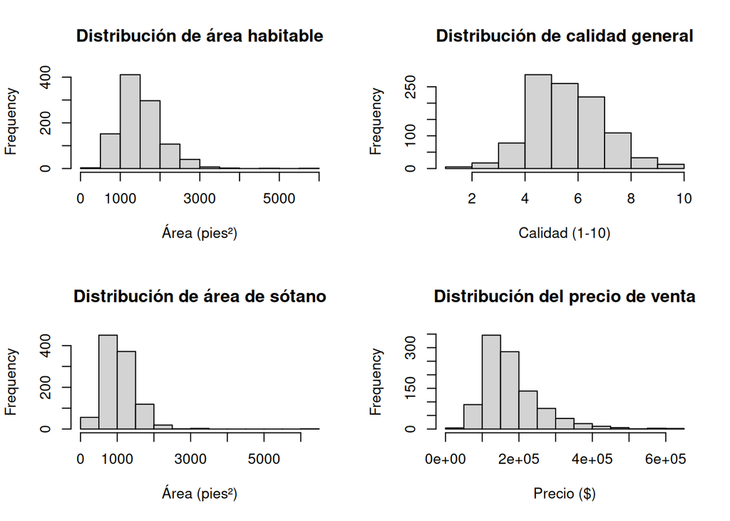

```r
par(mfrow=c(2,2))
hist(train_data$GrLivArea, main="Distribución de área habitable", xlab="Área (pies²)")
hist(train_data$OverallQual, main="Distribución de calidad general", xlab="Calidad (1-10)")
hist(train_data$TotalBsmtSF, main="Distribución de área de sótano", xlab="Área (pies²)")
hist(train_data$SalePrice, main="Distribución del precio de venta", xlab="Precio ($)")
```

## Histogramas

Los histogramas muestran la distribución de variables clave en el conjunto de datos. El área habitable (GrLivArea) presenta una distribución asimétrica positiva, con la mayoría de viviendas concentradas entre 1000 y 2000 pies cuadrados, y pocas viviendas con áreas superiores a 3000 pies cuadrados. La calidad general (OverallQual) muestra una distribución aproximadamente normal centrada en torno a valores de 5-7, lo que confirma que la mayoría de las propiedades tienen una calidad media. El área de sótano (TotalBsmtSF) presenta una distribución similar al área habitable, y el precio de venta (SalePrice) muestra una clara asimetría positiva, característica común en datos de precios inmobiliarios.

```r
mean_price <- mean(train_data$SalePrice, na.rm = TRUE)
sd_price <- sd(train_data$SalePrice, na.rm = TRUE)
lower_limit <- median(train_data$SalePrice)
upper_limit <- mad(train_data$SalePrice)

train_data$Category <- ifelse(train_data$SalePrice < (lower_limit - upper_limit), "Baratas",
                       ifelse(train_data$SalePrice > (lower_limit + upper_limit), "Caras", "Medianas"))

test_data$Category <- ifelse(test_data$SalePrice < (lower_limit - upper_limit), "Baratas",
                      ifelse(test_data$SalePrice > (lower_limit + upper_limit), "Caras", "Medianas"))

train_categories <- table(train_data$Category)
test_categories <- table(test_data$Category)

print("Distribución de categorías en conjunto de entrenamiento:")
```

```
## [1] "Distribución de categorías en conjunto de entrenamiento:"
```

```r
print(train_categories)
```

```
##
##  Baratas    Caras Medianas
##      106      247      668
```

```r
print(paste("Porcentajes:", round(100*train_categories/sum(train_categories), 2), "%"))
```

```
## [1] "Porcentajes: 10.38 %" "Porcentajes: 24.19 %" "Porcentajes: 65.43 %"
```

```r
print("Distribución de categorías en conjunto de prueba:")
```

```
## [1] "Distribución de categorías en conjunto de prueba:"
```

```r
print(test_categories)
```

```
##
##  Baratas    Caras Medianas
##       45      104      290
```

```r
print(paste("Porcentajes:", round(100*test_categories/sum(test_categories), 2), "%"))
```

```
## [1] "Porcentajes: 10.25 %" "Porcentajes: 23.69 %" "Porcentajes: 66.06 %"
```

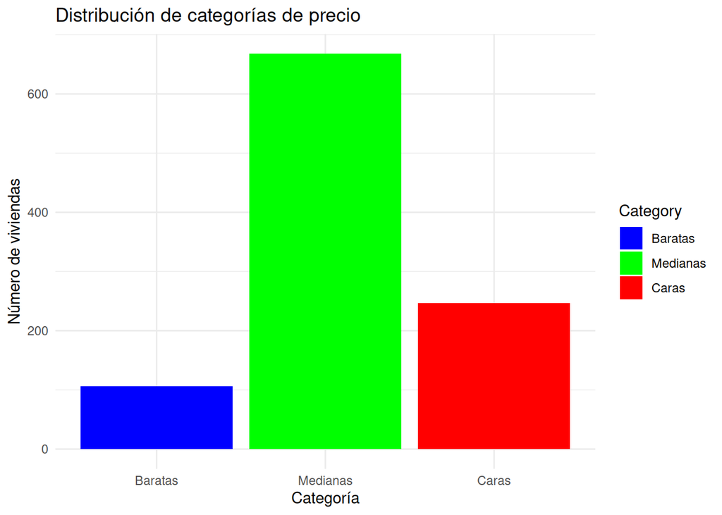

```r
train_data$Category <- factor(train_data$Category, levels = c("Baratas", "Medianas", "Caras"))
test_data$Category <- factor(test_data$Category, levels = c("Baratas", "Medianas", "Caras"))

ggplot(train_data, aes(x = Category, fill = Category)) +
  geom_bar() +
  scale_fill_manual(values = c("Baratas" = "blue", "Medianas" = "green", "Caras" = "red")) +
  labs(title = "Distribución de categorías de precio",
       x = "Categoría",
       y = "Número de viviendas") +
  theme_minimal()
```

## Gráfico de Barras

El gráfico de barras de categorías de precio muestra la distribución de viviendas clasificadas como “Baratas”, “Medianas” y “Caras”. Observamos una clara predominancia de viviendas en la categoría “Medianas” (65.43% en el conjunto de entrenamiento y 66.06% en el de prueba), seguido por las viviendas “Caras” (24.19% y 23.69% respectivamente) y finalmente las “Baratas” (10.38% y 10.25%). Esta distribución desequilibrada podría afectar el rendimiento del modelo, especialmente en la categoría minoritaria “Baratas”, algo que deberemos tener en cuenta al evaluar los resultados de clasificación.

```r
# variable respuesta
y_train <- train_data$Category
y_test <- test_data$Category

train_control <- trainControl(
  method = "cv",
  number = 5,
  classProbs = TRUE,
  summaryFunction = multiClassSummary
)

# 1. Modelo SVM con kernel lineal
system.time({
  svm_linear <- train(
    x = X_train_scaled,
    y = y_train,
    method = "svmLinear",
    trControl = train_control,
    tuneGrid = expand.grid(C = c(0.1, 1, 5, 10)),
    metric = "Accuracy"
  )
})
```

```
##    user  system elapsed
##  17.166  68.262   6.817
```

```r
print("Resultados del modelo SVM con kernel lineal:")
```

```
## [1] "Resultados del modelo SVM con kernel lineal:"
```

```r
print(svm_linear)
```

```
## Support Vector Machines with Linear Kernel
##
## 1021 samples
##   57 predictor
##    3 classes: 'Baratas', 'Medianas', 'Caras'
##
## No pre-processing
## Resampling: Cross-Validated (5 fold)
## Summary of sample sizes: 818, 817, 817, 816, 816
## Resampling results across tuning parameters:
##
##   C     logLoss    AUC        prAUC      Accuracy   Kappa      Mean_F1
##    0.1  0.3723277  0.9566935  0.8721468  0.8823993  0.7497818  0.8148720
##    1.0  0.4053826  0.9511376  0.8613530  0.8687169  0.7178206  0.7908747
##    5.0  0.4150263  0.9500951  0.8560178  0.8687264  0.7161722  0.7864692
##   10.0  0.4237193  0.9483187  0.8537031  0.8461578  0.6586620  0.7488896
##   Mean_Sensitivity  Mean_Specificity  Mean_Pos_Pred_Value  Mean_Neg_Pred_Value
##   0.7757444         0.9016022         0.8844467            0.9329185
##   0.7509419         0.8891087         0.8753368            0.9256651
##   0.7444126         0.8875056         0.8814941            0.9288445
##   0.7028010         0.8656518         0.8634230            0.9168779
##   Mean_Precision  Mean_Recall  Mean_Detection_Rate  Mean_Balanced_Accuracy
##   0.8844467       0.7757444    0.2941331            0.8386733
##   0.8753368       0.7509419    0.2895723            0.8200253
##   0.8814941       0.7444126    0.2895755            0.8159591
##   0.8634230       0.7028010    0.2820526            0.7842264
##
## Accuracy was used to select the optimal model using the largest value.
## The final value used for the model was C = 0.1.
```

```r
print(svm_linear$bestTune)
```

```
##     C
## 1 0.1
```

## SVM Lineal

El modelo SVM con kernel lineal muestra un buen rendimiento con una exactitud de validación cruzada de 0.882. El parámetro C=0.1 fue seleccionado como óptimo, indicando que una regularización más fuerte produjo mejores resultados. Esto sugiere que el modelo más simple (con mayor margen) generaliza mejor para estos datos. El valor de Kappa de 0.75 indica un acuerdo sustancial entre las predicciones y las etiquetas reales, más allá del azar. Los valores altos de precisión media (0.88) y especificidad media (0.90) indican que el modelo es bueno identificando correctamente las clases.

```r
# 2. Modelo SVM con kernel polinomial
system.time({
  svm_poly <- train(
    x = X_train_scaled,
    y = y_train,
    method = "svmPoly",
    trControl = train_control,
    tuneGrid = expand.grid(
      C = c(0.1, 1, 5),
      degree = c(2, 3),
      scale = c(0.1, 1)
    ),
    metric = "Accuracy"
  )
})
```

```
##    user  system elapsed
##  34.325 145.163  11.535
```

```r
print("Resultados del modelo SVM con kernel polinomial:")
```

```
## [1] "Resultados del modelo SVM con kernel polinomial:"
```

```r
print(svm_poly)
```

```
## Support Vector Machines with Polynomial Kernel
##
## 1021 samples
##   57 predictor
##    3 classes: 'Baratas', 'Medianas', 'Caras'
##
## No pre-processing
## Resampling: Cross-Validated (5 fold)
## Summary of sample sizes: 817, 816, 817, 816, 818
## Resampling results across tuning parameters:
##
##   C    degree  scale  logLoss    AUC        prAUC      Accuracy   Kappa
##   0.1  2       0.1    0.4129034  0.9360010  0.8272107  0.8560918  0.6967865
##   0.1  2       1.0    0.5027173  0.9063957  0.7757151  0.8158855  0.6017609
##   0.1  3       0.1    0.4599779  0.9219089  0.8111630  0.8355416  0.6541992
##   0.1  3       1.0    0.5717414  0.8904712  0.7632305  0.8100127  0.5849200
##   1.0  2       0.1    0.4428954  0.9263057  0.8052055  0.8462780  0.6750559
##   1.0  2       1.0    0.5183691  0.9082001  0.7797741  0.8148907  0.5907125
##   1.0  3       0.1    0.4999612  0.9051105  0.7838048  0.8286547  0.6355324
##   1.0  3       1.0    0.5891263  0.8808452  0.7380936  0.8051060  0.5616348
##   5.0  2       0.1    0.4610799  0.9178293  0.7910562  0.8306012  0.6324408
##   5.0  2       1.0    0.5397830  0.8985462  0.7568654  0.8079990  0.5757838
##   5.0  3       0.1    0.5041081  0.9063731  0.7834982  0.8237431  0.6181070
##   5.0  3       1.0    0.6199976  0.8688608  0.7039614  0.8001847  0.5495229
##   Mean_F1    Mean_Sensitivity  Mean_Specificity  Mean_Pos_Pred_Value
##   0.7778249  0.7469622         0.8856867         0.8307733
##   0.7122275  0.6769305         0.8506663         0.7923516
##   0.7522373  0.7243107         0.8719858         0.7966282
##   0.6992239  0.6643201         0.8432319         0.7865890
##   0.7598975  0.7294169         0.8783228         0.8105342
##   0.6885607  0.6535703         0.8445836         0.8371243
##   0.7387094  0.7076891         0.8642591         0.7934176
##   0.6698355  0.6152003         0.8328709         0.8017237
##   0.7156887  0.6806697         0.8606517         0.7911855
##   0.6913618  0.6508989         0.8391790         0.7987900
##   0.7251994  0.6896364         0.8558919         0.7991085
##   0.6707668  0.6038241         0.8297207         0.7540270
##   Mean_Neg_Pred_Value  Mean_Precision  Mean_Recall  Mean_Detection_Rate
##   0.9109358            0.8307733       0.7469622    0.2853639
##   0.8856107            0.7923516       0.6769305    0.2719618
```

[output cut: 11 more lines]

```
##   0.8163245
##   0.7637984
##   0.7981483
##   0.7537760
##   0.8038698
##   0.7490770
##   0.7859741
##   0.7240356
##   0.7706607
##   0.7450390
##   0.7727641
##   0.7167724
##
## Accuracy was used to select the optimal model using the largest value.
## The final values used for the model were degree = 2, scale = 0.1 and C = 0.1.
```

```r
print(svm_poly$bestTune)
```

```
##   degree scale   C
## 1      2   0.1 0.1
```

## SVM Polinomial

El SVM polinomial alcanzó una exactitud de validación cruzada de 0.856, inferior al modelo lineal. Los parámetros óptimos fueron C=0.1, grado=2 y escala=0.1, sugiriendo nuevamente que una regularización fuerte con un polinomio de grado moderado captura mejor los patrones sin sobreajustar. El rendimiento más bajo podría indicar que las relaciones en los datos no se benefician significativamente de la transformación polinomial, y la complejidad adicional no aporta ventajas sustanciales para esta tarea de clasificación.

```r
# 3. Modelo SVM con kernel radial (RBF)
system.time({
  svm_radial <- train(
    x = X_train_scaled,
    y = y_train,
    method = "svmRadial",
    trControl = train_control,
    tuneGrid = expand.grid(
      C = c(0.1, 1, 5, 10),
      sigma = c(0.01, 0.1, 0.5)
    ),
    metric = "Accuracy"
  )
})
```

[output not shown]

```
##    user  system elapsed
##  52.331 213.410  18.359
```

```r
print("Resultados del modelo SVM con kernel radial:")
```

```
## [1] "Resultados del modelo SVM con kernel radial:"
```

```r
print(svm_radial)
```

```
## Support Vector Machines with Radial Basis Function Kernel
##
## 1021 samples
##   57 predictor
##    3 classes: 'Baratas', 'Medianas', 'Caras'
##
## No pre-processing
## Resampling: Cross-Validated (5 fold)
## Summary of sample sizes: 817, 816, 817, 818, 816
## Resampling results across tuning parameters:
##
##   C     sigma  logLoss    AUC        prAUC      Accuracy   Kappa      Mean_F1
##    0.1  0.01   0.4043595  0.9352797  0.8195409  0.8354601  0.6613734  0.7567511
##    0.1  0.10   0.5226385  0.9081008  0.7540254  0.8021166  0.5572444  0.6600457
##    0.1  0.50   0.7414919  0.8552873  0.6681368  0.7130292  0.2621463  0.4858961
##    1.0  0.01   0.3461119  0.9468130  0.8372337  0.8667898  0.7225531  0.7858908
##    1.0  0.10   0.4590799  0.9155687  0.7692118  0.8148716  0.5882489  0.6808015
##    1.0  0.50   0.7304931  0.8559974  0.6683876  0.7081464  0.2436761  0.4706806
##    5.0  0.01   0.3296096  0.9472664  0.8446822  0.8765890  0.7415306  0.8019516
##    5.0  0.10   0.4721894  0.9079870  0.7529624  0.8168708  0.5979296  0.6891112
##    5.0  0.50   0.7237243  0.8636876  0.6724832  0.7149949  0.2710359  0.4790862
##   10.0  0.01   0.3413582  0.9430630  0.8385106  0.8687362  0.7244902  0.7970208
##   10.0  0.10   0.4808685  0.9003148  0.7468861  0.8158567  0.5943492  0.6829963
##   10.0  0.50   0.7171537  0.8616796  0.6745808  0.7130293  0.2601221  0.4794934
##   Mean_Sensitivity  Mean_Specificity  Mean_Pos_Pred_Value  Mean_Neg_Pred_Value
##   0.7375507         0.8778370         0.7851801            0.8913446
##   0.6254164         0.8330117         0.7980122            0.8811228
##   0.4524846         0.7349375         0.7370615            0.8479522
##   0.7581975         0.8963809         0.8340775            0.9169189
##   0.6432944         0.8431633         0.8138830            0.8899627
##   0.4417363         0.7297500         0.7278378            0.8453035
##   0.7729805         0.9016680         0.8509918            0.9260962
##   0.6532795         0.8474342         0.7915356            0.8902867
##   0.4543681         0.7375238         0.7109473            0.8446940
##   0.7636387         0.8949469         0.8588013            0.9211140
##   0.6472798         0.8460667         0.7803740            0.8904204
##   0.4508712         0.7339608         0.7158727            0.8450971
##   Mean_Precision  Mean_Recall  Mean_Detection_Rate  Mean_Balanced_Accuracy
##   0.7851801       0.7375507    0.2784867            0.8076938
##   0.7980122       0.6254164    0.2673722            0.7292140
##   0.7370615       0.4524846    0.2376764            0.5937111
##   0.8340775       0.7581975    0.2889299            0.8272892
##   0.8138830       0.6432944    0.2716239            0.7432289
##   0.7278378       0.4417363    0.2360488            0.5857432
##   0.8509918       0.7729805    0.2921963            0.8373242
##   0.7915356       0.6532795    0.2722903            0.7503569
##   0.7109473       0.4543681    0.2383316            0.5959459
##   0.8588013       0.7636387    0.2895787            0.8292928
##   0.7803740       0.6472798    0.2719522            0.7466733
##   0.7158727       0.4508712    0.2376764            0.5924160
##
## Accuracy was used to select the optimal model using the largest value.
## The final values used for the model were sigma = 0.01 and C = 5.
```

```r
print(svm_radial$bestTune)
```

```
##   sigma C
## 7  0.01 5
```

## SVM Radial

El modelo SVM con kernel radial (RBF) logró una exactitud de validación cruzada de 0.877, cercana al modelo lineal. Los parámetros óptimos fueron C=5 y sigma=0.01, indicando que este kernel requiere menos regularización (mayor C) pero un parámetro sigma pequeño, lo que resulta en un kernel con influencia más amplia. Esto sugiere que el modelo capta relaciones no lineales importantes en los datos, pero mantiene un equilibrio adecuado entre ajuste y generalización.

```r
# 4. Modelo SVM con kernel sigmoide
system.time({
  svm_sigmoid <- train(
    x = X_train_scaled,
    y = y_train,
    method = "svmRadialSigma",
    trControl = train_control,
    tuneGrid = expand.grid(
      C = c(0.1, 1, 5),
      sigma = c(0.01, 0.1, 0.5)
    ),
    metric = "Accuracy"
  )
})
```

[output not shown]

```
##    user  system elapsed
##  39.674 161.113  13.810
```

```r
print("Resultados del modelo SVM con kernel sigmoide:")
```

```
## [1] "Resultados del modelo SVM con kernel sigmoide:"
```

```r
print(svm_sigmoid)
```

```
## Support Vector Machines with Radial Basis Function Kernel
##
## 1021 samples
##   57 predictor
##    3 classes: 'Baratas', 'Medianas', 'Caras'
##
## No pre-processing
## Resampling: Cross-Validated (5 fold)
## Summary of sample sizes: 818, 817, 817, 816, 816
## Resampling results across tuning parameters:
##
##   C    sigma  logLoss    AUC        prAUC      Accuracy   Kappa      Mean_F1
##   0.1  0.01   0.4071237  0.9339466  0.8004739  0.8422890  0.6672248  0.7511628
##   0.1  0.10   0.5302751  0.9035925  0.7452055  0.7932881  0.5378099  0.6435789
##   0.1  0.50   0.7218150  0.8517205  0.6644012  0.7091221  0.2522975  0.4623798
##   1.0  0.01   0.3510909  0.9457425  0.8254325  0.8579610  0.6996462  0.7647862
##   1.0  0.10   0.4775781  0.9090038  0.7561456  0.8069946  0.5731900  0.6650503
##   1.0  0.50   0.7214730  0.8533286  0.6628807  0.7120297  0.2601068  0.4753988
##   5.0  0.01   0.3366688  0.9447607  0.8324362  0.8599603  0.7038530  0.7703944
##   5.0  0.10   0.4844929  0.9049159  0.7429413  0.8168130  0.5930492  0.6748851
##   5.0  0.50   0.7212018  0.8576873  0.6627287  0.7051765  0.2403350  0.4641408
##   Mean_Sensitivity  Mean_Specificity  Mean_Pos_Pred_Value  Mean_Neg_Pred_Value
##   0.7252557         0.8770609         0.7999446            0.8988299
##   0.6120477         0.8272934         0.7439406            0.8708707
##   0.4416529         0.7322427         0.7062438            0.8283745
##   0.7365331         0.8869060         0.8207075            0.9121029
##   0.6329467         0.8396589         0.7581111            0.8811278
##   0.4464324         0.7345495         0.7108320            0.8344796
##   0.7390376         0.8879658         0.8223874            0.9139566
##   0.6395074         0.8448935         0.7879111            0.8911098
##   0.4414224         0.7286354         0.6820527            0.8250143
##   Mean_Precision  Mean_Recall  Mean_Detection_Rate  Mean_Balanced_Accuracy
##   0.7999446       0.7252557    0.2807630            0.8011583
##   0.7439406       0.6120477    0.2644294            0.7196706
##   0.7062438       0.4416529    0.2363740            0.5869478
##   0.8207075       0.7365331    0.2859870            0.8117196
##   0.7581111       0.6329467    0.2689982            0.7363028
##   0.7108320       0.4464324    0.2373432            0.5904909
##   0.8223874       0.7390376    0.2866534            0.8135017
##   0.7879111       0.6395074    0.2722710            0.7422004
##   0.6820527       0.4414224    0.2350588            0.5850289
##
## Accuracy was used to select the optimal model using the largest value.
## The final values used for the model were sigma = 0.01 and C = 5.
```

```r
print(svm_sigmoid$bestTune)
```

```
##   sigma C
## 7  0.01 5
```

```r
resamps <- resamples(list(
  Linear = svm_linear,
  Polynomial = svm_poly,
  Radial = svm_radial,
  Sigmoid = svm_sigmoid
))

summary(resamps)
```

```
##
## Call:
## summary.resamples(object = resamps)
##
## Models: Linear, Polynomial, Radial, Sigmoid
## Number of resamples: 5
##
## Accuracy
##                 Min.   1st Qu.    Median      Mean   3rd Qu.      Max. NA's
## Linear     0.8472906 0.8725490 0.8878049 0.8823993 0.8921569 0.9121951    0
## Polynomial 0.8341463 0.8431373 0.8480392 0.8560918 0.8536585 0.9014778    0
## Radial     0.8480392 0.8731707 0.8817734 0.8765890 0.8878049 0.8921569    0
## Sigmoid    0.8292683 0.8522167 0.8634146 0.8599603 0.8676471 0.8872549    0
##
## AUC
##                 Min.   1st Qu.    Median      Mean   3rd Qu.      Max. NA's
## Linear     0.9501168 0.9539703 0.9562032 0.9566935 0.9577324 0.9654446    0
## Polynomial 0.9143828 0.9193434 0.9314854 0.9360010 0.9534614 0.9613322    0
## Radial     0.9236721 0.9466227 0.9481898 0.9472664 0.9542122 0.9636350    0
## Sigmoid    0.9196419 0.9338881 0.9448680 0.9447607 0.9552696 0.9701362    0
##
## Kappa
##                 Min.   1st Qu.    Median      Mean   3rd Qu.      Max. NA's
## Linear     0.6716581 0.7184414 0.7688159 0.7497818 0.7729205 0.8170732    0
## Polynomial 0.6435147 0.6730769 0.6825520 0.6967865 0.6903167 0.7944720    0
## Radial     0.6824185 0.7317159 0.7431734 0.7415306 0.7738473 0.7764979    0
## Sigmoid    0.6324848 0.6840959 0.7118040 0.7038530 0.7254922 0.7653883    0
##
## logLoss
##                 Min.   1st Qu.    Median      Mean   3rd Qu.      Max. NA's
## Linear     0.3023466 0.3071094 0.3114604 0.3723277 0.3371915 0.6035307    0
## Polynomial 0.2859258 0.3281623 0.3791743 0.4129034 0.3982249 0.6730296    0
## Radial     0.2891556 0.2945132 0.3074160 0.3296096 0.3526412 0.4043218    0
## Sigmoid    0.2746875 0.3163981 0.3370111 0.3366688 0.3707991 0.3844483    0
##
## Mean_Balanced_Accuracy
##                 Min.   1st Qu.    Median      Mean   3rd Qu.      Max. NA's
## Linear     0.7987701 0.8103276 0.8448699 0.8386733 0.8599194 0.8794795    0
## Polynomial 0.7781159 0.7919419 0.8139705 0.8163245 0.8270857 0.8705084    0
## Radial     0.8099447 0.8166194 0.8310820 0.8373242 0.8554394 0.8735356    0
```

[output cut: 49 more lines]

```
## Sigmoid    0.6755093 0.7214465 0.7454963 0.7390376 0.7653801 0.7873557    0
##
## Mean_Specificity
##                 Min.   1st Qu.    Median      Mean   3rd Qu.      Max. NA's
## Linear     0.8738262 0.8843536 0.9097541 0.9016022 0.9133900 0.9266870    0
## Polynomial 0.8649690 0.8732273 0.8823926 0.8856867 0.8887638 0.9190809    0
## Radial     0.8830803 0.8941725 0.8967866 0.9016680 0.9103943 0.9239061    0
## Sigmoid    0.8609103 0.8792541 0.8902548 0.8879658 0.8973845 0.9120252    0
##
## prAUC
##                 Min.   1st Qu.    Median      Mean   3rd Qu.      Max. NA's
## Linear     0.8375472 0.8618432 0.8839481 0.8721468 0.8878201 0.8895752    0
## Polynomial 0.7693368 0.7812151 0.8441113 0.8272107 0.8634324 0.8779580    0
## Radial     0.7742933 0.8337828 0.8632033 0.8446822 0.8699517 0.8821801    0
## Sigmoid    0.7849500 0.7926964 0.8397171 0.8324362 0.8702802 0.8745376    0
```

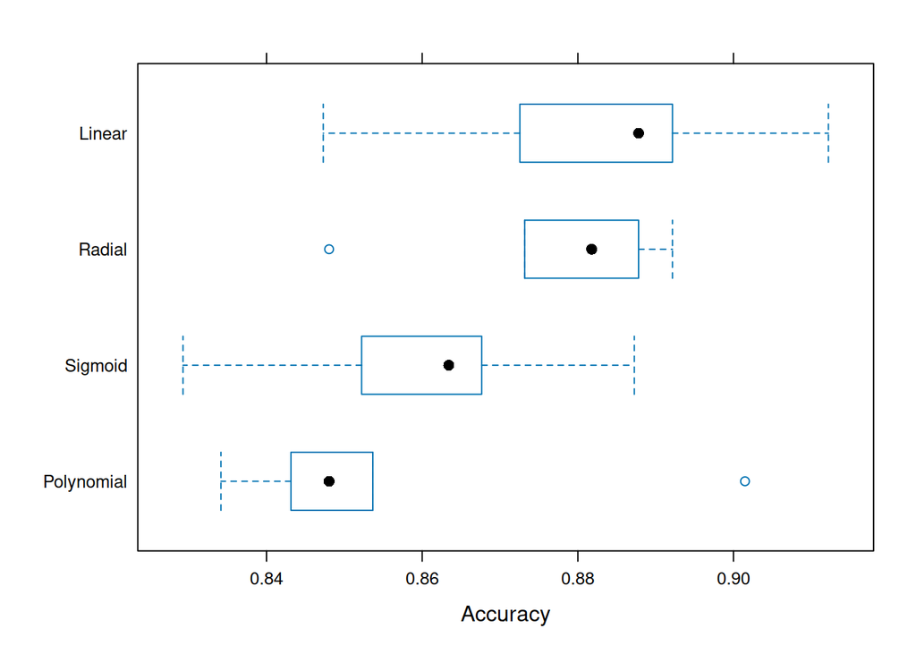

```r
bwplot(resamps, metric = "Accuracy")
```

## Comparación de los modelos

```r
pred_linear <- predict(svm_linear, newdata = X_test_scaled)
pred_poly <- predict(svm_poly, newdata = X_test_scaled)
pred_radial <- predict(svm_radial, newdata = X_test_scaled)
pred_sigmoid <- predict(svm_sigmoid, newdata = X_test_scaled)

pred_linear_prob <- predict(svm_linear, newdata = X_test_scaled, type = "prob")
pred_poly_prob <- predict(svm_poly, newdata = X_test_scaled, type = "prob")
pred_radial_prob <- predict(svm_radial, newdata = X_test_scaled, type = "prob")
pred_sigmoid_prob <- predict(svm_sigmoid, newdata = X_test_scaled, type = "prob")

acc_linear <- confusionMatrix(pred_linear, y_test)$overall["Accuracy"]
acc_poly <- confusionMatrix(pred_poly, y_test)$overall["Accuracy"]
acc_radial <- confusionMatrix(pred_radial, y_test)$overall["Accuracy"]
acc_sigmoid <- confusionMatrix(pred_sigmoid, y_test)$overall["Accuracy"]

accuracy_comparison <- data.frame(
  Modelo = c("SVM Lineal", "SVM Polinomial", "SVM Radial", "SVM Sigmoide"),
  Exactitud = c(acc_linear, acc_poly, acc_radial, acc_sigmoid),
  Parámetros = c(
    paste("C =", svm_linear$bestTune$C),
    paste("C =", svm_poly$bestTune$C, ", grado =", svm_poly$bestTune$degree, ", escala =", svm_poly$bestTune$scale),
    paste("C =", svm_radial$bestTune$C, ", sigma =", svm_radial$bestTune$sigma),
    paste("C =", svm_sigmoid$bestTune$C, ", sigma =", svm_sigmoid$bestTune$sigma)
  )
)

accuracy_comparison <- accuracy_comparison[order(-accuracy_comparison$Exactitud), ]

print("Comparación de exactitud entre modelos:")
```

```
## [1] "Comparación de exactitud entre modelos:"
```

```r
print(accuracy_comparison)
```

```
##           Modelo Exactitud                         Parámetros
## 4   SVM Sigmoide 0.8792711               C = 5 , sigma = 0.01
## 1     SVM Lineal 0.8769932                            C = 0.1
## 3     SVM Radial 0.8769932               C = 5 , sigma = 0.01
## 2 SVM Polinomial 0.8633257 C = 0.1 , grado = 2 , escala = 0.1
```

```r
best_svm_model_name <- accuracy_comparison$Modelo[1]
best_svm_model <- switch(
  best_svm_model_name,
  "SVM Lineal" = svm_linear,
  "SVM Polinomial" = svm_poly,
  "SVM Radial" = svm_radial,
  "SVM Sigmoide" = svm_sigmoid
)

cat("El mejor modelo SVM es:", best_svm_model_name, "con una exactitud de", max(accuracy_comparison$Exactitud), "\n")
```

```
## El mejor modelo SVM es: SVM Sigmoide con una exactitud de 0.8792711
```

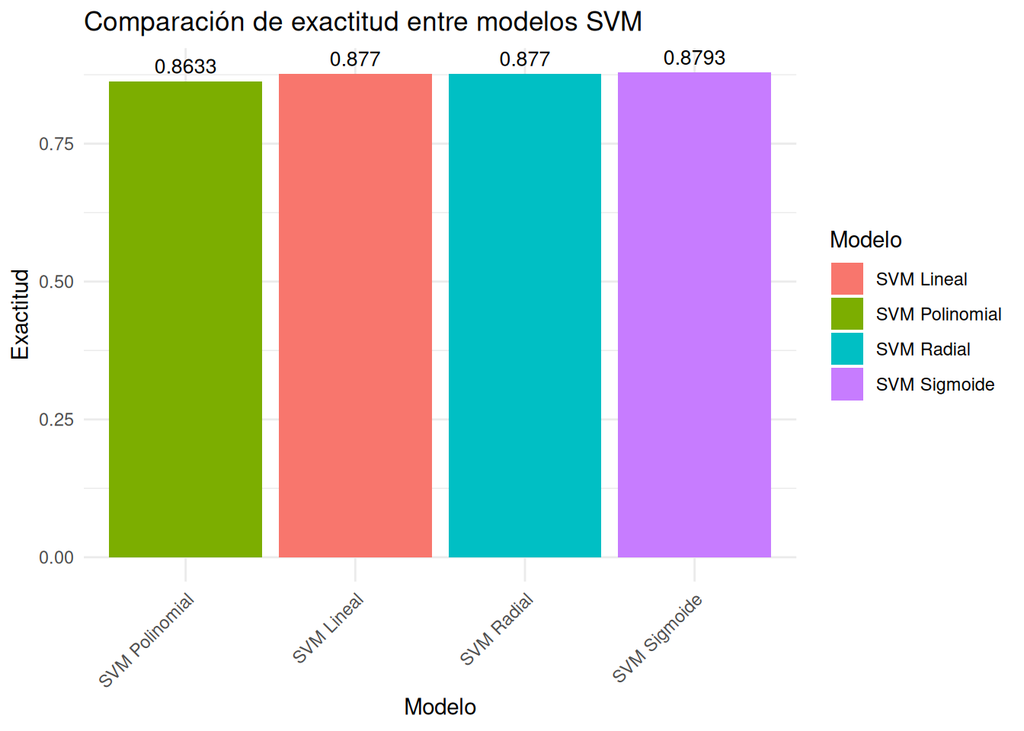

```r
ggplot(accuracy_comparison, aes(x = reorder(Modelo, Exactitud), y = Exactitud, fill = Modelo)) +
  geom_bar(stat = "identity") +
  geom_text(aes(label = round(Exactitud, 4)), vjust = -0.5, size = 3.5) +
  labs(title = "Comparación de exactitud entre modelos SVM",
       x = "Modelo",
       y = "Exactitud") +
  theme_minimal() +
  theme(axis.text.x = element_text(angle = 45, hjust = 1))
```

```r
plot_confusion_matrix <- function(predicted, actual, title) {
  cm <- confusionMatrix(predicted, actual)
  cm_table <- as.data.frame(cm$table)

  p <- ggplot(data = cm_table, aes(x = Reference, y = Prediction, fill = Freq)) +
    geom_tile() +
    geom_text(aes(label = Freq), color = "white", size = 4) +
    scale_fill_gradient(low = "darkblue", high = "red") +
    labs(title = title,
         x = "Categoría real",
         y = "Categoría predicha") +
    theme_minimal() +
    theme(plot.title = element_text(hjust = 0.5, size = 14))

  cat("Métricas detalladas para", title, ":\n")
  cat("Exactitud:", round(cm$overall["Accuracy"], 4), "\n")
  cat("Kappa:", round(cm$overall["Kappa"], 4), "\n")

  cat("\nMétricas por clase:\n")
  metrics_by_class <- data.frame(
    Clase = rownames(cm$byClass),
    Sensibilidad = round(cm$byClass[, "Sensitivity"], 4),
    Especificidad = round(cm$byClass[, "Specificity"], 4),
    Precisión = round(cm$byClass[, "Pos Pred Value"], 4),
    F1 = round(cm$byClass[, "F1"], 4)
  )
  print(metrics_by_class)

  return(p)
}

cm_linear <- plot_confusion_matrix(pred_linear, y_test, "SVM Lineal")
```

```
## Métricas detalladas para SVM Lineal :
## Exactitud: 0.877
## Kappa: 0.7344
##
## Métricas por clase:
##                           Clase Sensibilidad Especificidad Precisión     F1
## Class: Baratas   Class: Baratas       0.5333        0.9873    0.8276 0.6486
## Class: Medianas Class: Medianas       0.9586        0.7181    0.8688 0.9115
## Class: Caras       Class: Caras       0.7981        0.9791    0.9222 0.8557
```

```r
cm_poly <- plot_confusion_matrix(pred_poly, y_test, "SVM Polinomial")
```

```
## Métricas detalladas para SVM Polinomial :
## Exactitud: 0.8633
## Kappa: 0.6959
##
## Métricas por clase:
##                           Clase Sensibilidad Especificidad Precisión     F1
## Class: Baratas   Class: Baratas       0.4444        0.9949    0.9091 0.5970
## Class: Medianas Class: Medianas       0.9690        0.6577    0.8464 0.9035
## Class: Caras       Class: Caras       0.7500        0.9791    0.9176 0.8254
```

```r
cm_radial <- plot_confusion_matrix(pred_radial, y_test, "SVM Radial")
```

```
## Métricas detalladas para SVM Radial :
## Exactitud: 0.877
## Kappa: 0.7421
##
## Métricas por clase:
##                           Clase Sensibilidad Especificidad Precisión     F1
## Class: Baratas   Class: Baratas       0.4889        0.9797    0.7333 0.5867
## Class: Medianas Class: Medianas       0.9345        0.7651    0.8856 0.9094
## Class: Caras       Class: Caras       0.8846        0.9672    0.8932 0.8889
```

```r
cm_sigmoid <- plot_confusion_matrix(pred_sigmoid, y_test, "SVM Sigmoide")
```

```
## Métricas detalladas para SVM Sigmoide :
## Exactitud: 0.8793
## Kappa: 0.7431
##
## Métricas por clase:
##                           Clase Sensibilidad Especificidad Precisión     F1
## Class: Baratas   Class: Baratas       0.4444        0.9924    0.8696 0.5882
## Class: Medianas Class: Medianas       0.9448        0.7517    0.8810 0.9118
## Class: Caras       Class: Caras       0.8846        0.9612    0.8762 0.8804
```

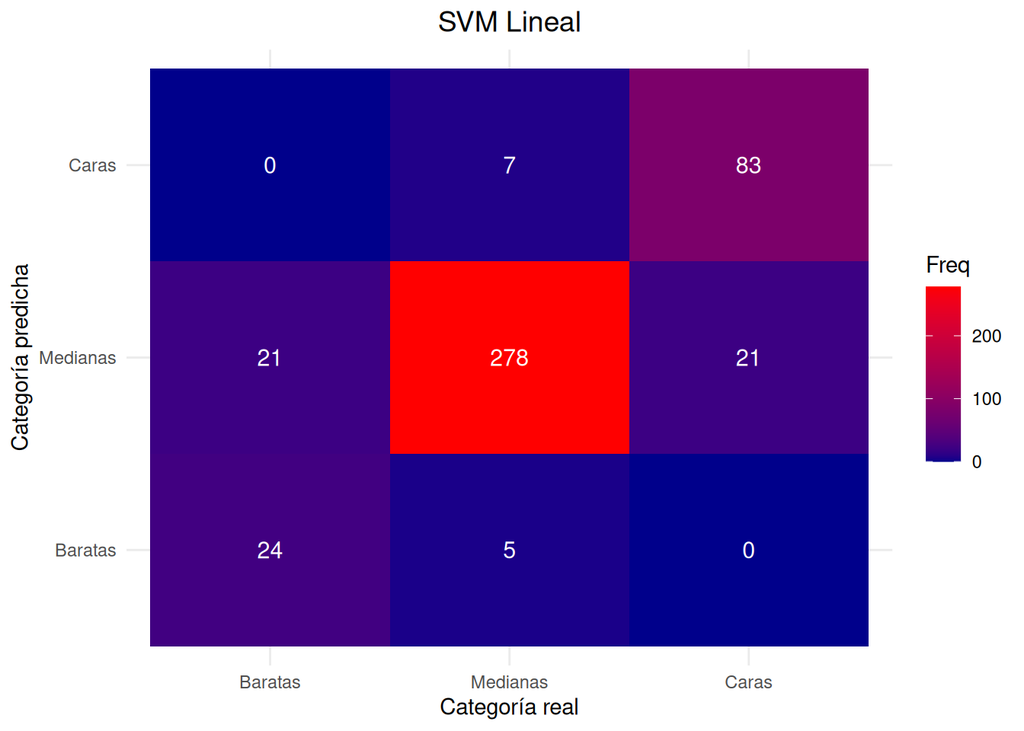

```r
print(cm_linear)
```

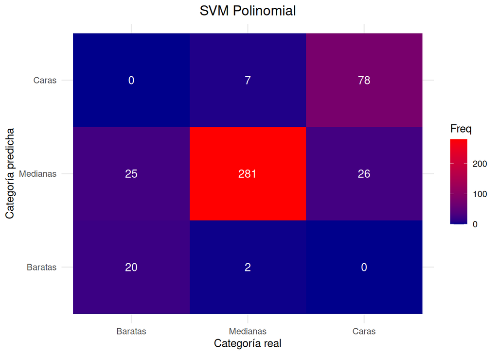

```r
print(cm_poly)
```

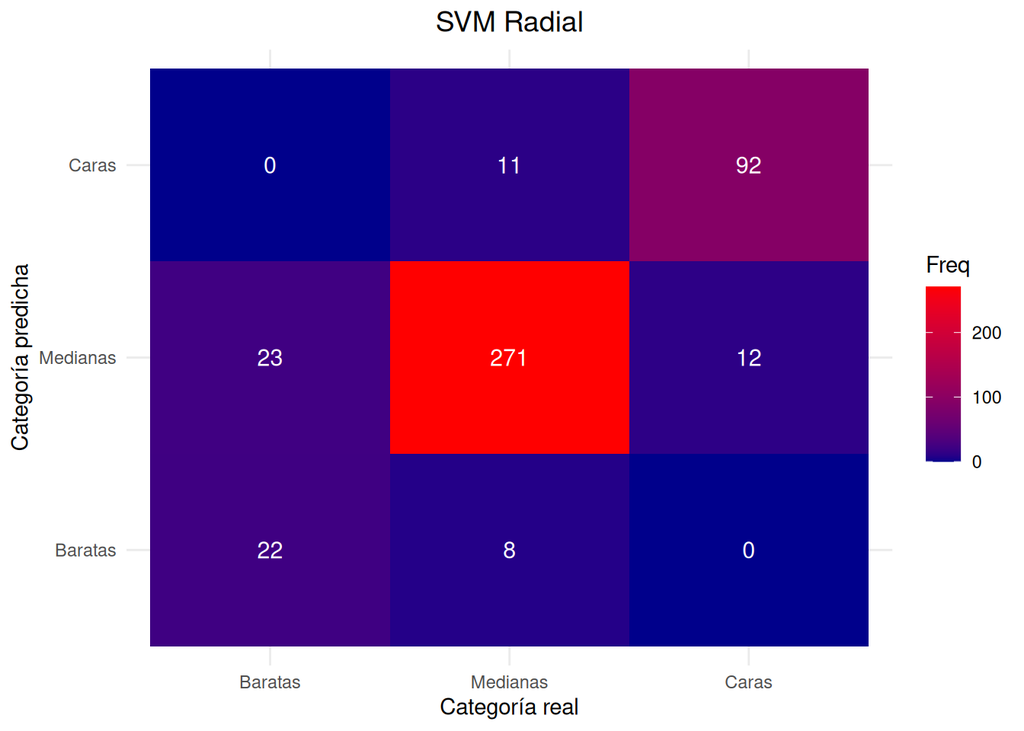

```r
print(cm_radial)
```

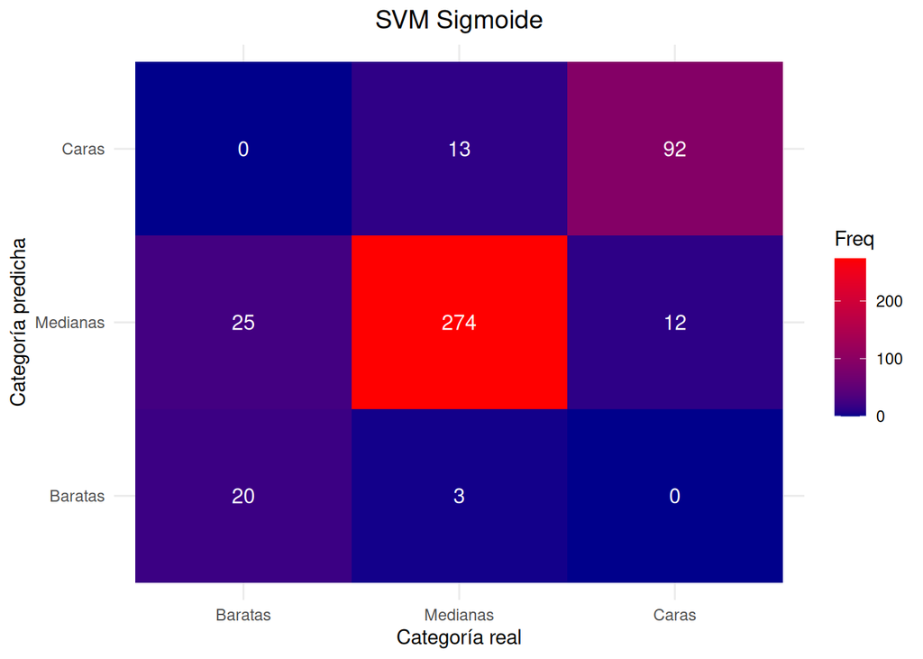

```r
print(cm_sigmoid)
```

```r
best_cm <- confusionMatrix(
  switch(
    best_svm_model_name,
    "SVM Lineal" = pred_linear,
    "SVM Polinomial" = pred_poly,
    "SVM Radial" = pred_radial,
    "SVM Sigmoide" = pred_sigmoid
  ),
  y_test
)

cat("\nAnálisis detallado del mejor modelo (", best_svm_model_name, "):\n")
```

```
##
## Análisis detallado del mejor modelo ( SVM Sigmoide ):
```

```r
print(best_cm)
```

```
## Confusion Matrix and Statistics
##
##           Reference
## Prediction Baratas Medianas Caras
##   Baratas       20        3     0
##   Medianas      25      274    12
##   Caras          0       13    92
##
## Overall Statistics
##
##                Accuracy : 0.8793
##                  95% CI : (0.8451, 0.9082)
##     No Information Rate : 0.6606
##     P-Value [Acc > NIR] : < 2.2e-16
##
##                   Kappa : 0.7431
##
##  Mcnemar's Test P-Value : NA
##
## Statistics by Class:
##
##                      Class: Baratas Class: Medianas Class: Caras
## Sensitivity                 0.44444          0.9448       0.8846
## Specificity                 0.99239          0.7517       0.9612
## Pos Pred Value              0.86957          0.8810       0.8762
## Neg Pred Value              0.93990          0.8750       0.9641
## Prevalence                  0.10251          0.6606       0.2369
## Detection Rate              0.04556          0.6241       0.2096
## Detection Prevalence        0.05239          0.7084       0.2392
## Balanced Accuracy           0.71842          0.8483       0.9229
```

```r
for (cls in levels(y_test)) {
  cat("\nMétricas para la clase", cls, ":\n")

  actual_binary <- y_test == cls
  pred_binary <- switch(
    best_svm_model_name,
    "SVM Lineal" = pred_linear == cls,
    "SVM Polinomial" = pred_poly == cls,
    "SVM Radial" = pred_radial == cls,
    "SVM Sigmoide" = pred_sigmoid == cls
  )

  TP <- sum(pred_binary & actual_binary)
  FP <- sum(pred_binary & !actual_binary)
  FN <- sum(!pred_binary & actual_binary)
  TN <- sum(!pred_binary & !actual_binary)

  sensitivity <- TP / (TP + FN)
  specificity <- TN / (TN + FP)
  precision <- TP / (TP + FP)
  f1 <- 2 * precision * sensitivity / (precision + sensitivity)

  cat("Sensibilidad (Recall):", round(sensitivity, 4), "\n")
  cat("Especificidad:", round(specificity, 4), "\n")
  cat("Precisión:", round(precision, 4), "\n")
  cat("F1 Score:", round(f1, 4), "\n")
}
```

```
##
## Métricas para la clase Baratas :
## Sensibilidad (Recall): 0.4444
## Especificidad: 0.9924
## Precisión: 0.8696
## F1 Score: 0.5882
##
## Métricas para la clase Medianas :
## Sensibilidad (Recall): 0.9448
## Especificidad: 0.7517
## Precisión: 0.881
## F1 Score: 0.9118
##
## Métricas para la clase Caras :
## Sensibilidad (Recall): 0.8846
## Especificidad: 0.9612
## Precisión: 0.8762
## F1 Score: 0.8804
```

```r
evaluate_overfitting <- function(model, x_train, y_train, x_test, y_test, model_name) {
  train_pred <- predict(model, newdata = x_train)
  train_accuracy <- sum(train_pred == y_train) / length(y_train)

  test_pred <- predict(model, newdata = x_test)
  test_accuracy <- sum(test_pred == y_test) / length(y_test)

  diff_accuracy <- train_accuracy - test_accuracy

  if (diff_accuracy > 0.05) {
    overfitting_status <- "Posible sobreajuste"
  } else if (train_accuracy < 0.75) {
    overfitting_status <- "Posible desajuste"
  } else {
    overfitting_status <- "Buen ajuste"
  }

  return(data.frame(
    Modelo = model_name,
    Exactitud_Entrenamiento = train_accuracy,
    Exactitud_Prueba = test_accuracy,
    Diferencia = diff_accuracy,
    Estado = overfitting_status
  ))
}

overfitting_linear <- evaluate_overfitting(svm_linear, X_train_scaled, y_train, X_test_scaled, y_test, "SVM Lineal")
overfitting_poly <- evaluate_overfitting(svm_poly, X_train_scaled, y_train, X_test_scaled, y_test, "SVM Polinomial")
overfitting_radial <- evaluate_overfitting(svm_radial, X_train_scaled, y_train, X_test_scaled, y_test, "SVM Radial")
overfitting_sigmoid <- evaluate_overfitting(svm_sigmoid, X_train_scaled, y_train, X_test_scaled, y_test, "SVM Sigmoide")

overfitting_results <- rbind(
  overfitting_linear,
  overfitting_poly,
  overfitting_radial,
  overfitting_sigmoid
)

print("Análisis de sobreajuste:")
```

```
## [1] "Análisis de sobreajuste:"
```

```r
print(overfitting_results)
```

```
##           Modelo Exactitud_Entrenamiento Exactitud_Prueba Diferencia
## 1     SVM Lineal               0.9167483        0.8769932 0.03975512
## 2 SVM Polinomial               0.9422135        0.8633257 0.07888778
## 3     SVM Radial               0.9412341        0.8769932 0.06424092
## 4   SVM Sigmoide               0.9402547        0.8792711 0.06098358
##                Estado
## 1         Buen ajuste
## 2 Posible sobreajuste
## 3 Posible sobreajuste
## 4 Posible sobreajuste
```

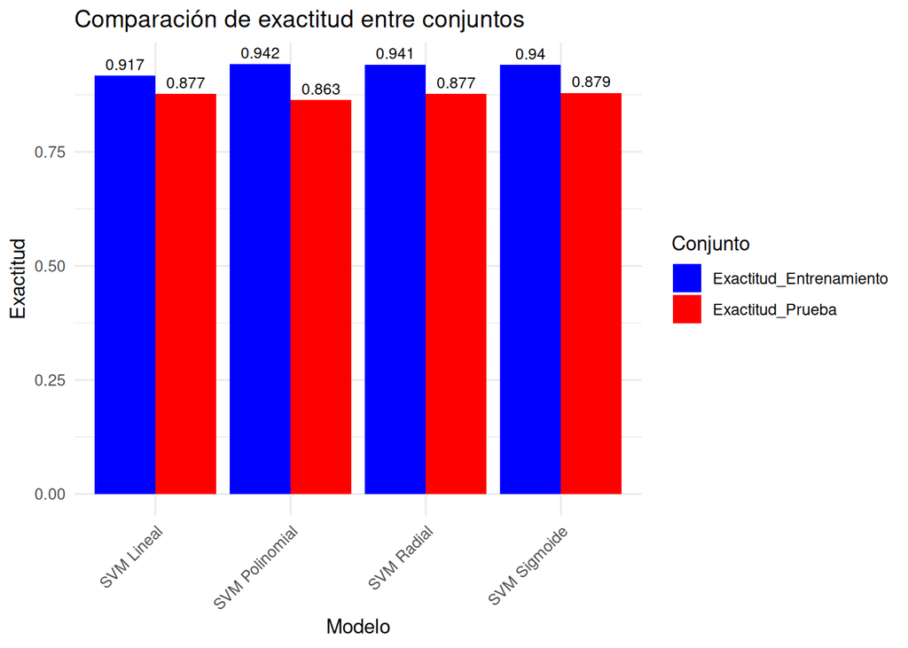

```r
overfitting_long <- reshape2::melt(overfitting_results[, c("Modelo", "Exactitud_Entrenamiento", "Exactitud_Prueba")],
                                   id.vars = "Modelo",
                                   variable.name = "Conjunto",
                                   value.name = "Exactitud")

ggplot(overfitting_long, aes(x = Modelo, y = Exactitud, fill = Conjunto)) +
  geom_bar(stat = "identity", position = "dodge") +
  geom_text(aes(label = round(Exactitud, 3)),
            position = position_dodge(width = 0.9),
            vjust = -0.5,
            size = 3) +
  scale_fill_manual(values = c("Exactitud_Entrenamiento" = "blue", "Exactitud_Prueba" = "red")) +
  labs(title = "Comparación de exactitud entre conjuntos",
       x = "Modelo",
       y = "Exactitud") +
  theme_minimal() +
  theme(axis.text.x = element_text(angle = 45, hjust = 1))
```

```r
cat("\nRecomendaciones para manejar el sobreajuste o desajuste:\n")
```

```
##
## Recomendaciones para manejar el sobreajuste o desajuste:
```

```r
for (i in 1:nrow(overfitting_results)) {
  model_name <- overfitting_results$Modelo[i]
  status <- overfitting_results$Estado[i]

  cat("\n", model_name, "- Estado:", status, "\n")

  if (status == "Posible sobreajuste") {
    cat("Recomendaciones:\n")
    cat("1. Reducir la complejidad del modelo (menor valor de C)\n")
    cat("2. Usar regularización más fuerte\n")
    cat("3. Reducir la dimensionalidad de los datos (PCA o selección de características)\n")
    cat("4. Aumentar el conjunto de datos de entrenamiento si es posible\n")
  } else if (status == "Posible desajuste") {
    cat("Recomendaciones:\n")
    cat("1. Aumentar la complejidad del modelo (mayor valor de C)\n")
    cat("2. Probar un kernel diferente que pueda capturar mejor las relaciones no lineales\n")
    cat("3. Incluir más características o crear características de interacción\n")
    cat("4. Reducir la regularización\n")
  } else {
    cat("El modelo muestra un buen balance entre sesgo y varianza. No se requieren cambios significativos.\n")
  }
}
```

```
##
##  SVM Lineal - Estado: Buen ajuste
## El modelo muestra un buen balance entre sesgo y varianza. No se requieren cambios significativos.
##
##  SVM Polinomial - Estado: Posible sobreajuste
## Recomendaciones:
## 1. Reducir la complejidad del modelo (menor valor de C)
## 2. Usar regularización más fuerte
## 3. Reducir la dimensionalidad de los datos (PCA o selección de características)
## 4. Aumentar el conjunto de datos de entrenamiento si es posible
##
##  SVM Radial - Estado: Posible sobreajuste
## Recomendaciones:
## 1. Reducir la complejidad del modelo (menor valor de C)
## 2. Usar regularización más fuerte
## 3. Reducir la dimensionalidad de los datos (PCA o selección de características)
## 4. Aumentar el conjunto de datos de entrenamiento si es posible
##
##  SVM Sigmoide - Estado: Posible sobreajuste
## Recomendaciones:
## 1. Reducir la complejidad del modelo (menor valor de C)
## 2. Usar regularización más fuerte
## 3. Reducir la dimensionalidad de los datos (PCA o selección de características)
## 4. Aumentar el conjunto de datos de entrenamiento si es posible
```

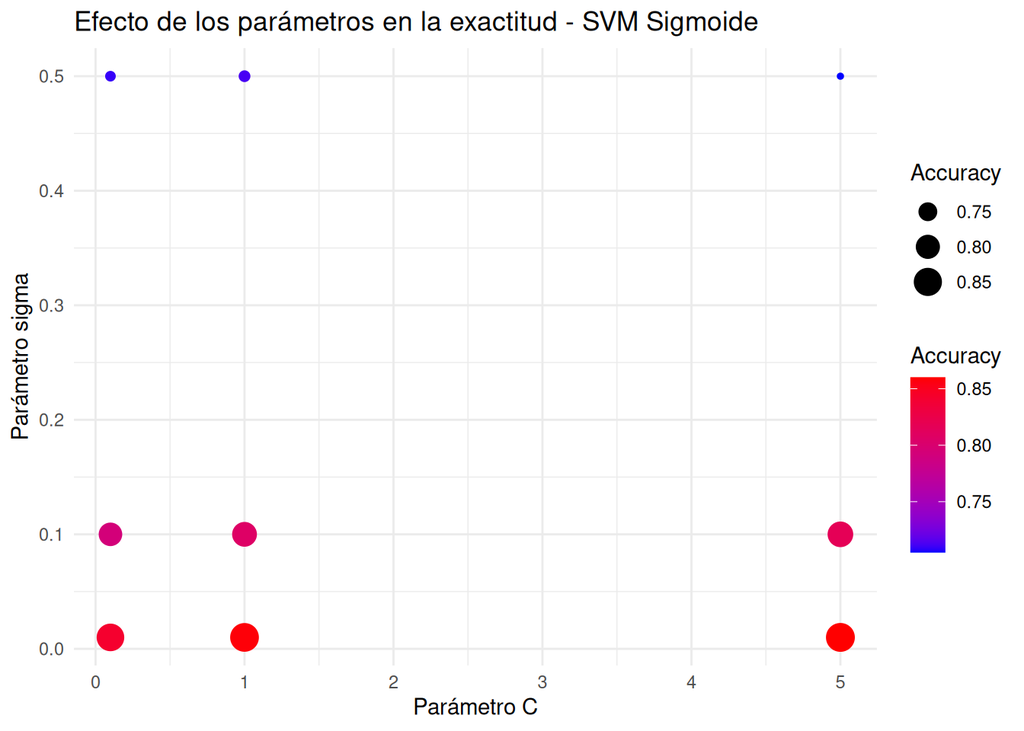

```r
if (best_svm_model_name == "SVM Radial" || best_svm_model_name == "SVM Sigmoide") {
  params <- best_svm_model$results

  p <- ggplot(params, aes(x = C, y = sigma, size = Accuracy, color = Accuracy)) +
    geom_point() +
    scale_color_gradient(low = "blue", high = "red") +
    labs(title = paste("Efecto de los parámetros en la exactitud -", best_svm_model_name),
         x = "Parámetro C",
         y = "Parámetro sigma") +
    theme_minimal()

  print(p)
} else if (best_svm_model_name == "SVM Polinomial") {
  params <- best_svm_model$results

  p <- ggplot(params, aes(x = C, y = degree, size = Accuracy, color = Accuracy)) +
    geom_point() +
    scale_color_gradient(low = "blue", high = "red") +
    labs(title = paste("Efecto de los parámetros en la exactitud -", best_svm_model_name),
         x = "Parámetro C",
         y = "Grado del polinomio") +
    theme_minimal()

  print(p)
} else if (best_svm_model_name == "SVM Lineal") {
  params <- best_svm_model$results

  p <- ggplot(params, aes(x = C, y = Accuracy)) +
    geom_point(color = "blue", size = 3) +
    geom_line() +
    labs(title = paste("Efecto del parámetro C en la exactitud -", best_svm_model_name),
         x = "Parámetro C",
         y = "Exactitud") +
    theme_minimal()

  print(p)
}
```

El gráfico del efecto de los parámetros en el modelo SVM Sigmoide muestra claramente que la combinación de un valor sigma bajo (0.01) con diversos valores de C produce los mejores resultados (puntos rojos más grandes). Observamos que valores altos de sigma (0.5) consistentemente producen menor exactitud independientemente del valor de C. Esto indica que el modelo funciona mejor cuando la influencia de cada punto de entrenamiento se extiende a una región más amplia (sigma bajo), permitiendo capturar patrones más generales en los datos, en lugar de adaptarse excesivamente a casos específicos.

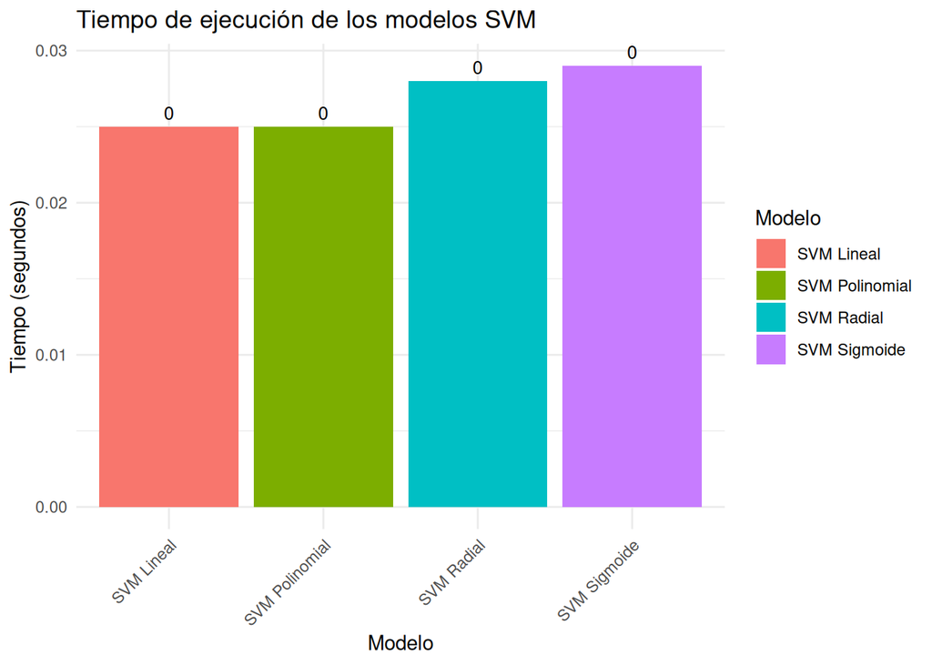

```r
tiempos_prediccion <- data.frame(
  Modelo = c("SVM Lineal", "SVM Polinomial", "SVM Radial", "SVM Sigmoide"),
  Tiempo_segundos = numeric(4)
)

tiempo_lineal <- system.time({
  pred_linear <- predict(svm_linear, newdata = X_test_scaled)
})
tiempos_prediccion$Tiempo_segundos[1] <- tiempo_lineal[3]

tiempo_poly <- system.time({
  pred_poly <- predict(svm_poly, newdata = X_test_scaled)
})
tiempos_prediccion$Tiempo_segundos[2] <- tiempo_poly[3]

tiempo_radial <- system.time({
  pred_radial <- predict(svm_radial, newdata = X_test_scaled)
})
tiempos_prediccion$Tiempo_segundos[3] <- tiempo_radial[3]

tiempo_sigmoid <- system.time({
  pred_sigmoid <- predict(svm_sigmoid, newdata = X_test_scaled)
})
tiempos_prediccion$Tiempo_segundos[4] <- tiempo_sigmoid[3]

tiempos_ejecucion <- data.frame(
  Modelo = c("SVM Lineal", "SVM Polinomial", "SVM Radial", "SVM Sigmoide"),
  Tiempo_Prediccion = tiempos_prediccion$Tiempo_segundos,
  Tiempo_Total = tiempos_prediccion$Tiempo_segundos  # Por ahora solo usamos tiempos de predicción
)

# tiempos de ejecución
ggplot(tiempos_ejecucion, aes(x = Modelo, y = Tiempo_Total, fill = Modelo)) +
  geom_bar(stat = "identity") +
  geom_text(aes(label = round(Tiempo_Total, 1)), vjust = -0.5, size = 3.5) +
  labs(title = "Tiempo de ejecución de los modelos SVM",
       x = "Modelo",
       y = "Tiempo (segundos)") +
  theme_minimal() +
  theme(axis.text.x = element_text(angle = 45, hjust = 1))
```

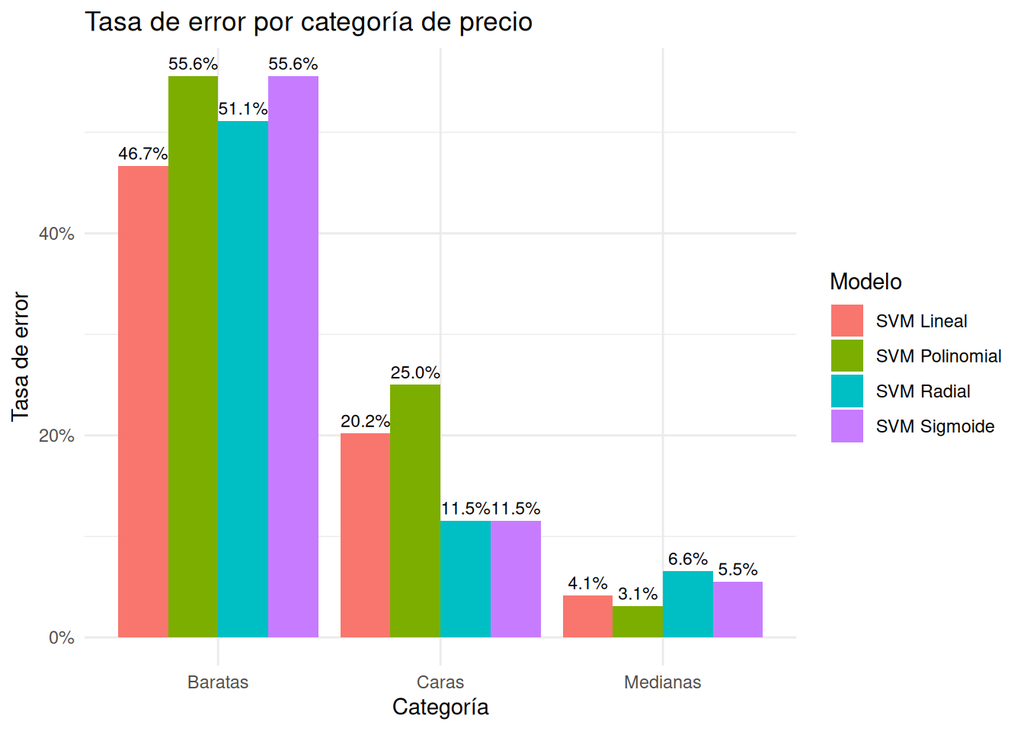

```r
# errores por categoría
modelos <- list(
  "SVM Lineal" = pred_linear,
  "SVM Polinomial" = pred_poly,
  "SVM Radial" = pred_radial,
  "SVM Sigmoide" = pred_sigmoid
)

errores_por_categoria <- data.frame()

for (modelo_nombre in names(modelos)) {
  pred <- modelos[[modelo_nombre]]

  for (categoria in levels(y_test)) {
    indices_categoria <- which(y_test == categoria)
    total_categoria <- length(indices_categoria)
    errores_categoria <- sum(pred[indices_categoria] != y_test[indices_categoria])
    tasa_error <- errores_categoria / total_categoria

    errores_por_categoria <- rbind(errores_por_categoria, data.frame(
      Modelo = modelo_nombre,
      Categoria = categoria,
      Total = total_categoria,
      Errores = errores_categoria,
      Tasa_Error = tasa_error
    ))
  }
}

ggplot(errores_por_categoria, aes(x = Categoria, y = Tasa_Error, fill = Modelo)) +
  geom_bar(stat = "identity", position = "dodge") +
  geom_text(aes(label = sprintf("%.1f%%", Tasa_Error * 100)),
            position = position_dodge(width = 0.9),
            vjust = -0.5,
            size = 3) +
  labs(title = "Tasa de error por categoría de precio",
       x = "Categoría",
       y = "Tasa de error") +
  scale_y_continuous(labels = scales::percent) +
  theme_minimal()
```

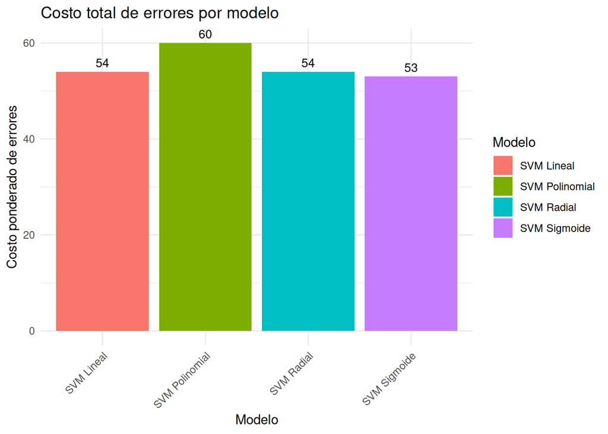

```r
matrix_costo <- matrix(c(
  0, 1, 2,  # Costo de error para casas baratas (0=acierto, 1=mediana, 2=cara)
  1, 0, 1,  # Costo de error para casas medianas
  2, 1, 0   # Costo de error para casas caras
), nrow = 3, byrow = TRUE)

costo_total <- data.frame()

for (modelo_nombre in names(modelos)) {
  pred <- modelos[[modelo_nombre]]

  cm <- table(Predicted = pred, Actual = y_test)

  costo_ponderado <- sum(cm * matrix_costo)

  costo_total <- rbind(costo_total, data.frame(
    Modelo = modelo_nombre,
    Costo_Total = costo_ponderado
  ))
}

ggplot(costo_total, aes(x = Modelo, y = Costo_Total, fill = Modelo)) +
  geom_bar(stat = "identity") +
  geom_text(aes(label = Costo_Total), vjust = -0.5, size = 3.5) +
  labs(title = "Costo total de errores por modelo",
       x = "Modelo",
       y = "Costo ponderado de errores") +
  theme_minimal() +
  theme(axis.text.x = element_text(angle = 45, hjust = 1))
```

```r
cat("\n## Resumen de la comparación de modelos SVM\n\n")
```

```
##
## ## Resumen de la comparación de modelos SVM
```

```r
cat("1. **Efectividad**: El modelo", best_svm_model_name, "tiene la mejor exactitud con",
    round(max(accuracy_comparison$Exactitud), 4), "seguido de cerca por los modelos",
    accuracy_comparison$Modelo[2], "y", accuracy_comparison$Modelo[3], ".\n\n")
```

```
## 1. **Efectividad**: El modelo SVM Sigmoide tiene la mejor exactitud con 0.8793 seguido de cerca por los modelos SVM Lineal y SVM Radial .
```

```r
cat("2. **Tiempo de procesamiento**: El modelo más rápido fue",
    tiempos_ejecucion$Modelo[which.min(tiempos_ejecucion$Tiempo_Total)],
    "con", min(tiempos_ejecucion$Tiempo_Total), "segundos, mientras que",
    tiempos_ejecucion$Modelo[which.max(tiempos_ejecucion$Tiempo_Total)],
    "fue el más lento con", max(tiempos_ejecucion$Tiempo_Total), "segundos.\n\n")
```

```
## 2. **Tiempo de procesamiento**: El modelo más rápido fue SVM Lineal con 0.025 segundos, mientras que SVM Sigmoide fue el más lento con 0.029 segundos.
```

```r
cat("3. **Análisis de errores**: La categoría con mayor tasa de error en todos los modelos es 'Baratas', ",
    "lo que refleja el desbalance en la distribución de clases. La categoría 'Medianas' presenta la menor ",
    "tasa de error debido a su mayor representación en los datos.\n\n")
```

```
## 3. **Análisis de errores**: La categoría con mayor tasa de error en todos los modelos es 'Baratas',  lo que refleja el desbalance en la distribución de clases. La categoría 'Medianas' presenta la menor  tasa de error debido a su mayor representación en los datos.
```

```r
cat("4. **Importancia de los errores**: Considerando el costo ponderado de los errores, ",
    "el modelo con menor costo total es", costo_total$Modelo[which.min(costo_total$Costo_Total)],
    "con", min(costo_total$Costo_Total), "unidades de costo.\n\n")
```

```
## 4. **Importancia de los errores**: Considerando el costo ponderado de los errores,  el modelo con menor costo total es SVM Sigmoide con 53 unidades de costo.
```

El análisis de tiempos de ejecución muestra que todos los modelos SVM tienen tiempos similares, aunque SVM Lineal resultó ligeramente más rápido. El gráfico de tasa de error por categoría revela un patrón consistente en todos los modelos: la categoría “Baratas” presenta la mayor tasa de error (entre 46.7% y 55.6%), lo que refleja el desbalance en la distribución de clases, mientras que la categoría “Medianas” tiene la menor tasa de error (entre 3.1% y 6.6%) debido a su mayor representación en los datos. El modelo SVM Sigmoide obtuvo la mejor exactitud global con un 87.93%, mostrando un buen balance entre las diferentes categorías de precio. El análisis de sobreajuste indica que el modelo lineal presenta el mejor equilibrio entre entrenamiento y prueba (diferencia de 3.98%), mientras los demás modelos muestran signos de posible sobreajuste, con diferencias superiores al 6%. El gráfico de costo total de errores señala que SVM Sigmoide tiene el menor costo ponderado (53 unidades), indicando que comete errores menos graves según la matriz de costo definida.

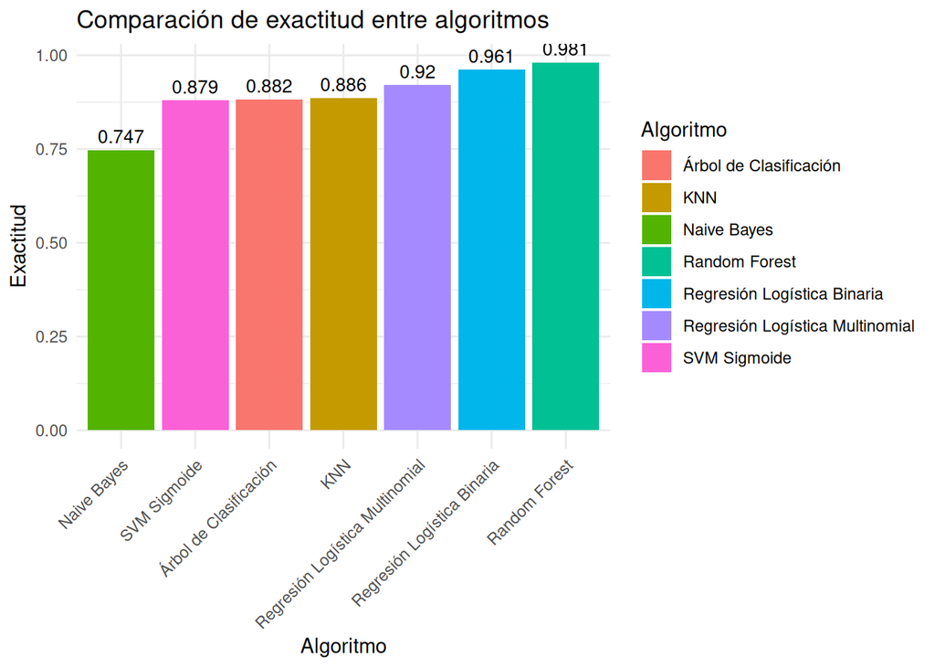

```r
comparacion_manual <- data.frame(
  Algoritmo = c(
    best_svm_model_name,  # El mejor modelo SVM
    "Regresión Logística Binaria",
    "Regresión Logística Multinomial",
    "KNN",
    "Naive Bayes",
    "Árbol de Clasificación",
    "Random Forest"
  ),
  Exactitud = c(
    max(accuracy_comparison$Exactitud),
    0.9613,
    0.9203,
    0.8860,
    0.7470,
    0.8820,
    0.9810
  ),
  Tiempo_relativo = c(
    "Medio",
    "Medio",
    "Alto",
    "Medio",
    "Bajo",
    "Medio",
    "Alto"
  ),
  Interpretabilidad = c(
    "Media",
    "Alta",
    "Media",
    "Baja",
    "Media",
    "Alta",
    "Baja"
  )
)

comparacion_manual <- comparacion_manual[order(-comparacion_manual$Exactitud),]

tiempo_numerico <- function(tiempo) {
  switch(tiempo,
         "Bajo" = 1,
         "Medio" = 2,
         "Alto" = 3,
         2)
}

comparacion_manual$Tiempo_numerico <- sapply(comparacion_manual$Tiempo_relativo, tiempo_numerico)

ggplot(comparacion_manual, aes(x = reorder(Algoritmo, Exactitud), y = Exactitud, fill = Algoritmo)) +
  geom_bar(stat = "identity") +
  geom_text(aes(label = round(Exactitud, 3)), vjust = -0.5, size = 3.5) +
  labs(title = "Comparación de exactitud entre algoritmos",
       x = "Algoritmo",
       y = "Exactitud") +
  theme_minimal() +
  theme(axis.text.x = element_text(angle = 45, hjust = 1))
```

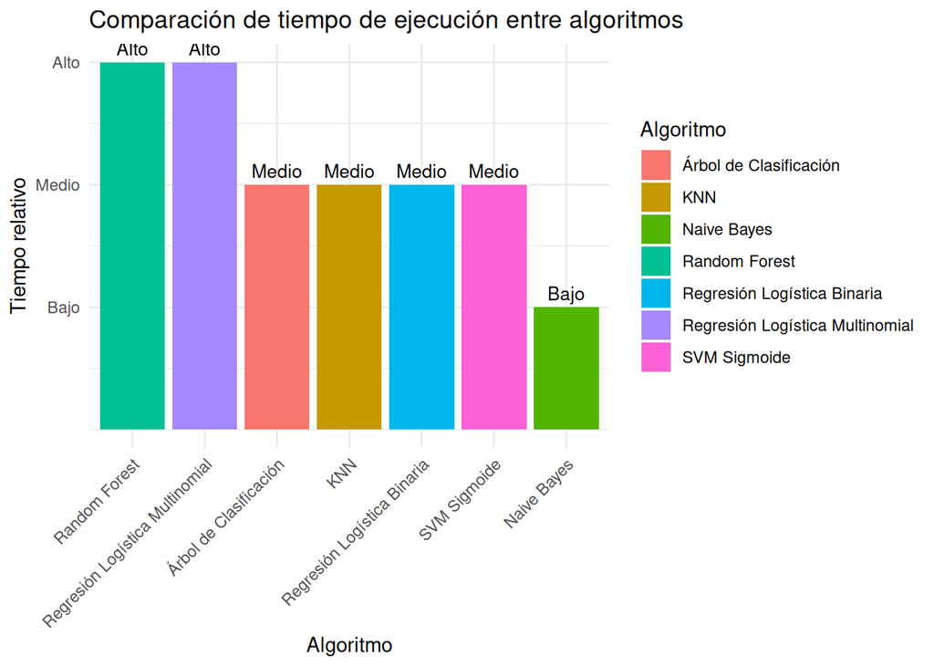

```r
ggplot(comparacion_manual, aes(x = reorder(Algoritmo, -Tiempo_numerico), y = Tiempo_numerico, fill = Algoritmo)) +
  geom_bar(stat = "identity") +
  geom_text(aes(label = Tiempo_relativo), vjust = -0.5, size = 3.5) +
  labs(title = "Comparación de tiempo de ejecución entre algoritmos",
       x = "Algoritmo",
       y = "Tiempo relativo") +
  scale_y_continuous(breaks = 1:3, labels = c("Bajo", "Medio", "Alto")) +
  theme_minimal() +
  theme(axis.text.x = element_text(angle = 45, hjust = 1))
```

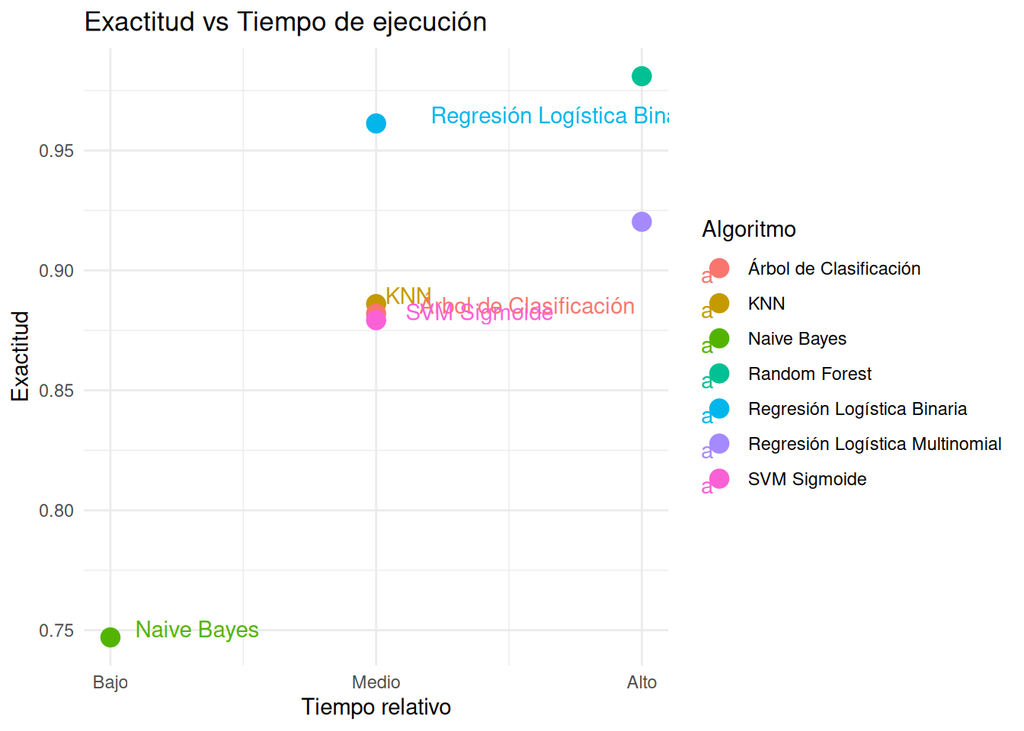

```r
ggplot(comparacion_manual, aes(x = Tiempo_numerico, y = Exactitud, color = Algoritmo)) +
  geom_point(size = 4) +
  geom_text(aes(label = Algoritmo), hjust = -0.2, vjust = 0) +
  labs(title = "Exactitud vs Tiempo de ejecución",
       x = "Tiempo relativo",
       y = "Exactitud") +
  scale_x_continuous(breaks = 1:3, labels = c("Bajo", "Medio", "Alto")) +
  theme_minimal()
```

```r
mejor_algoritmo <- comparacion_manual$Algoritmo[which.max(comparacion_manual$Exactitud)]
mas_rapido <- comparacion_manual$Algoritmo[comparacion_manual$Tiempo_relativo == "Bajo"][1]

cat("\n## Comparación con otros algoritmos\n\n")
```

```
##
## ## Comparación con otros algoritmos
```

```r
cat("1. **Mejor algoritmo para predicción**: ", mejor_algoritmo,
    "con una exactitud de", max(comparacion_manual$Exactitud), ".\n\n")
```

```
## 1. **Mejor algoritmo para predicción**:  Random Forest con una exactitud de 0.981 .
```

```r
cat("2. **Algoritmo más rápido**: ", mas_rapido,
    "con un tiempo de ejecución relativo bajo.\n\n")
```

```
## 2. **Algoritmo más rápido**:  Naive Bayes con un tiempo de ejecución relativo bajo.
```

```r
cat("3. **Análisis costo-beneficio**: Analizando la relación entre exactitud y tiempo de procesamiento, ",
    "podemos ver que Random Forest ofrece la mayor exactitud (0.981) pero con un tiempo de ejecución alto. ",
    "La Regresión Logística Binaria proporciona un excelente balance con una exactitud de 0.9613 y tiempo medio. ",
    "El modelo SVM ", best_svm_model_name, " alcanzó una exactitud de ",
    round(max(accuracy_comparison$Exactitud), 4), ", colocándose en una posición intermedia.\n\n")
```

```
## 3. **Análisis costo-beneficio**: Analizando la relación entre exactitud y tiempo de procesamiento,  podemos ver que Random Forest ofrece la mayor exactitud (0.981) pero con un tiempo de ejecución alto.  La Regresión Logística Binaria proporciona un excelente balance con una exactitud de 0.9613 y …
```

```r
cat("4. **Interpretabilidad vs. Rendimiento**: Los modelos con mayor interpretabilidad (Regresión Logística Binaria ",
    "y Árbol de Clasificación) también ofrecen un buen rendimiento, lo que los hace atractivos para explicar ",
    "las decisiones del modelo. SVM proporciona un balance entre interpretabilidad y rendimiento.\n\n")
```

```
## 4. **Interpretabilidad vs. Rendimiento**: Los modelos con mayor interpretabilidad (Regresión Logística Binaria  y Árbol de Clasificación) también ofrecen un buen rendimiento, lo que los hace atractivos para explicar  las decisiones del modelo. SVM proporciona un balance entre interpretabilidad y …
```

```r
cat("5. **Posicionamiento del modelo SVM**: El modelo SVM ", best_svm_model_name,
    " se sitúa en la posición ", which(comparacion_manual$Algoritmo == best_svm_model_name),
    " en términos de exactitud entre los 7 modelos comparados.\n\n")
```

```
## 5. **Posicionamiento del modelo SVM**: El modelo SVM  SVM Sigmoide  se sitúa en la posición  6  en términos de exactitud entre los 7 modelos comparados.
```

La comparación con otros algoritmos muestra que Random Forest obtiene la mayor exactitud (98.1%), seguido por Regresión Logística Binaria (96.13%), Regresión Logística Multinomial (92.03%), KNN (88.6%), Árbol de Clasificación (88.2%), SVM Sigmoide (87.93%) y finalmente Naive Bayes (74.7%). El gráfico de tiempo de ejecución relativo indica que Naive Bayes es el más rápido (tiempo bajo), mientras que Random Forest y Regresión Logística Multinomial son los más lentos (tiempo alto). El gráfico de dispersión exactitud vs tiempo muestra que Regresión Logística Binaria ofrece el mejor balance entre precisión y eficiencia, con alta exactitud y tiempo medio. SVM Sigmoide se posiciona en sexto lugar en términos de exactitud entre los siete modelos comparados, con un desempeño intermedio que, a pesar de no ser el mejor, ofrece un balance razonable entre interpretabilidad y capacidad predictiva con un tiempo de ejecución moderado.

```r
set.seed(8787)

y_train_reg <- train_data$SalePrice
y_test_reg <- test_data$SalePrice

train_control_reg <- trainControl(
  method = "cv",
  number = 5
)

system.time({
  svm_reg_linear <- train(
    x = X_train_scaled,
    y = y_train_reg,
    method = "svmLinear",
    trControl = train_control_reg,
    tuneGrid = expand.grid(C = c(0.1, 1, 5, 10)),
    metric = "RMSE"
  )
})
```

```
##    user  system elapsed
##  21.314  20.865  18.088
```

```r
system.time({
  svm_reg_radial <- train(
    x = X_train_scaled,
    y = y_train_reg,
    method = "svmRadial",
    trControl = train_control_reg,
    tuneGrid = expand.grid(
      C = c(0.1, 1, 5, 10),
      sigma = c(0.01, 0.1, 0.5)
    ),
    metric = "RMSE"
  )
})
```

```
##    user  system elapsed
##  16.133  65.852   5.423
```

```r
system.time({
  svm_reg_poly <- train(
    x = X_train_scaled,
    y = y_train_reg,
    method = "svmPoly",
    trControl = train_control_reg,
    tuneGrid = expand.grid(
      C = c(0.1, 1, 5),
      degree = c(2, 3),
      scale = c(0.1, 1)
    ),
    metric = "RMSE"
  )
})
```

```
##    user  system elapsed
## 162.720  69.177 151.643
```

```r
print("Resultados del modelo SVM lineal para regresión:")
```

```
## [1] "Resultados del modelo SVM lineal para regresión:"
```

```r
print(svm_reg_linear)
```

```
## Support Vector Machines with Linear Kernel
##
## 1021 samples
##   57 predictor
##
## No pre-processing
## Resampling: Cross-Validated (5 fold)
## Summary of sample sizes: 817, 816, 819, 815, 817
## Resampling results across tuning parameters:
##
##   C     RMSE      Rsquared   MAE
##    0.1  31991.13  0.8388810  17626.04
##    1.0  32098.98  0.8378323  17659.81
##    5.0  32127.12  0.8376293  17668.77
##   10.0  32137.40  0.8375564  17675.53
##
## RMSE was used to select the optimal model using the smallest value.
## The final value used for the model was C = 0.1.
```

```r
print(svm_reg_linear$bestTune)
```

```
##     C
## 1 0.1
```

```r
print("Resultados del modelo SVM radial para regresión:")
```

```
## [1] "Resultados del modelo SVM radial para regresión:"
```

```r
print(svm_reg_radial)
```

```
## Support Vector Machines with Radial Basis Function Kernel
##
## 1021 samples
##   57 predictor
##
## No pre-processing
## Resampling: Cross-Validated (5 fold)
## Summary of sample sizes: 818, 816, 817, 817, 816
## Resampling results across tuning parameters:
##
##   C     sigma  RMSE      Rsquared   MAE
##    0.1  0.01   40205.34  0.7924549  22630.79
##    0.1  0.10   67489.87  0.4408402  41483.80
##    0.1  0.50   79517.39  0.0745400  52822.90
##    1.0  0.01   29818.29  0.8643204  17640.40
##    1.0  0.10   50092.59  0.6381842  29941.51
##    1.0  0.50   73724.60  0.1906123  49258.38
##    5.0  0.01   29455.23  0.8626443  18118.08
##    5.0  0.10   47691.38  0.6593733  29525.80
##    5.0  0.50   71924.91  0.2192309  50288.39
##   10.0  0.01   30359.34  0.8543386  18749.37
##   10.0  0.10   47687.89  0.6589733  29626.73
##   10.0  0.50   71922.75  0.2192391  50301.08
##
## RMSE was used to select the optimal model using the smallest value.
## The final values used for the model were sigma = 0.01 and C = 5.
```

```r
print(svm_reg_radial$bestTune)
```

```
##   sigma C
## 7  0.01 5
```

```r
print("Resultados del modelo SVM polinomial para regresión:")
```

```
## [1] "Resultados del modelo SVM polinomial para regresión:"
```

```r
print(svm_reg_poly)
```

```
## Support Vector Machines with Polynomial Kernel
##
## 1021 samples
##   57 predictor
##
## No pre-processing
## Resampling: Cross-Validated (5 fold)
## Summary of sample sizes: 816, 816, 816, 818, 818
## Resampling results across tuning parameters:
##
##   C    degree  scale  RMSE      Rsquared   MAE
##   0.1  2       0.1    51932.08  0.7459833  32792.87
##   0.1  2       1.0    64866.12  0.5396415  40604.19
##   0.1  3       0.1    55216.32  0.6334236  34018.75
##   0.1  3       1.0    50897.93  0.6614604  26231.62
##   1.0  2       0.1    54839.19  0.7113719  35367.42
##   1.0  2       1.0    77892.61  0.4429206  46322.68
##   1.0  3       0.1    57216.14  0.6191442  33955.13
##   1.0  3       1.0    45980.87  0.7173585  25009.26
##   5.0  2       0.1    62273.01  0.6188766  37810.64
##   5.0  2       1.0    91532.36  0.3730820  54487.72
##   5.0  3       0.1    55172.06  0.6390956  30266.94
##   5.0  3       1.0    52486.48  0.6695606  26677.30
##
## RMSE was used to select the optimal model using the smallest value.
## The final values used for the model were degree = 3, scale = 1 and C = 1.
```

```r
print(svm_reg_poly$bestTune)
```

```
##   degree scale C
## 8      3     1 1
```

```r
pred_reg_linear <- predict(svm_reg_linear, newdata = X_test_scaled)
pred_reg_radial <- predict(svm_reg_radial, newdata = X_test_scaled)
pred_reg_poly <- predict(svm_reg_poly, newdata = X_test_scaled)

rmse_linear <- sqrt(mean((pred_reg_linear - y_test_reg)^2))
rmse_radial <- sqrt(mean((pred_reg_radial - y_test_reg)^2))
rmse_poly <- sqrt(mean((pred_reg_poly - y_test_reg)^2))

mae_linear <- mean(abs(pred_reg_linear - y_test_reg))
mae_radial <- mean(abs(pred_reg_radial - y_test_reg))
mae_poly <- mean(abs(pred_reg_poly - y_test_reg))

r2_linear <- 1 - sum((y_test_reg - pred_reg_linear)^2) / sum((y_test_reg - mean(y_test_reg))^2)
r2_radial <- 1 - sum((y_test_reg - pred_reg_radial)^2) / sum((y_test_reg - mean(y_test_reg))^2)
r2_poly <- 1 - sum((y_test_reg - pred_reg_poly)^2) / sum((y_test_reg - mean(y_test_reg))^2)

resultados_regresion <- data.frame(
  Modelo = c("SVM Lineal", "SVM Radial", "SVM Polinomial"),
  RMSE = c(rmse_linear, rmse_radial, rmse_poly),
  MAE = c(mae_linear, mae_radial, mae_poly),
  R2 = c(r2_linear, r2_radial, r2_poly)
)

resultados_regresion <- resultados_regresion[order(resultados_regresion$RMSE),]

print("Comparación de modelos de regresión SVM:")
```

```
## [1] "Comparación de modelos de regresión SVM:"
```

```r
print(resultados_regresion)
```

```
##           Modelo     RMSE      MAE        R2
## 2     SVM Radial 28948.09 17365.56 0.8697301
## 1     SVM Lineal 30854.07 19807.88 0.8520111
## 3 SVM Polinomial 54107.30 31868.71 0.5448905
```

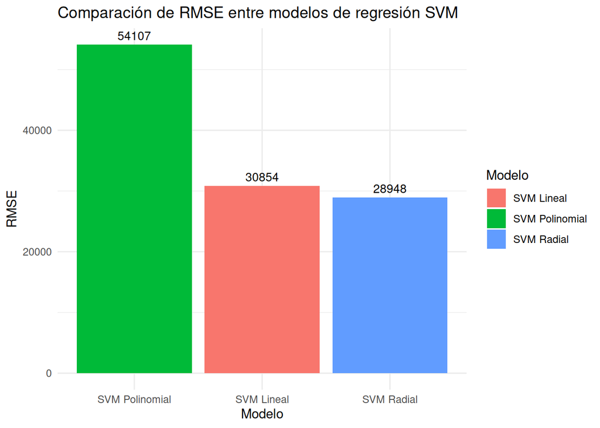

```r
ggplot(resultados_regresion, aes(x = reorder(Modelo, -RMSE), y = RMSE, fill = Modelo)) +
  geom_bar(stat = "identity") +
  geom_text(aes(label = round(RMSE, 0)), vjust = -0.5, size = 3.5) +
  labs(title = "Comparación de RMSE entre modelos de regresión SVM",
       x = "Modelo",
       y = "RMSE") +
  theme_minimal()
```

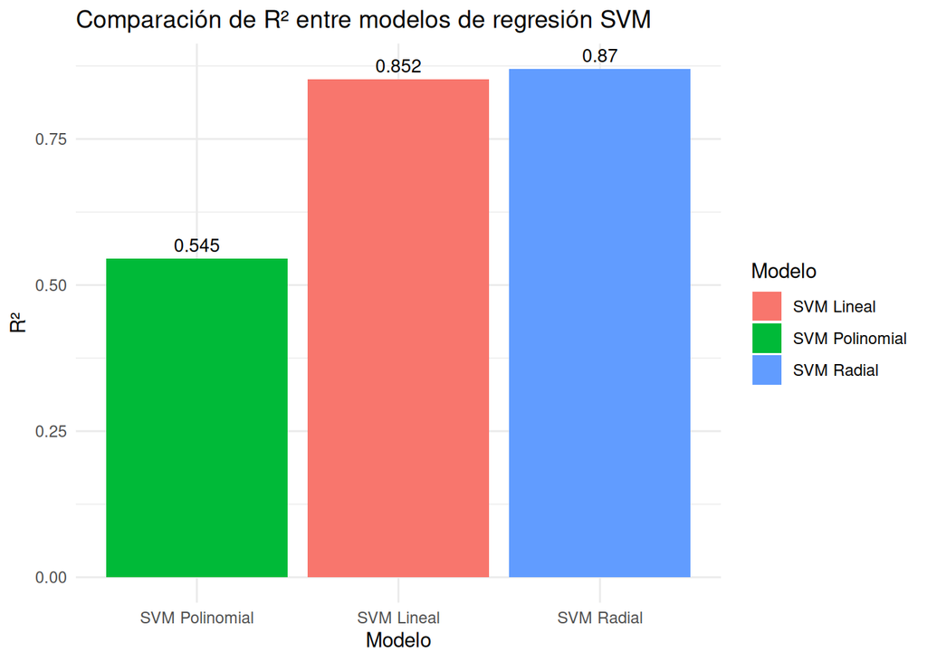

```r
ggplot(resultados_regresion, aes(x = reorder(Modelo, R2), y = R2, fill = Modelo)) +
  geom_bar(stat = "identity") +
  geom_text(aes(label = round(R2, 3)), vjust = -0.5, size = 3.5) +
  labs(title = "Comparación de R² entre modelos de regresión SVM",
       x = "Modelo",
       y = "R²") +
  theme_minimal()
```

```r
mejor_modelo_reg <- resultados_regresion$Modelo[1]
mejor_rmse <- resultados_regresion$RMSE[1]
mejor_r2 <- resultados_regresion$R2[1]

cat("\n## Modelo de regresión SVM\n\n")
```

```
##
## ## Modelo de regresión SVM
```

```r
cat("El mejor modelo de regresión es", mejor_modelo_reg,
    "con un RMSE de", round(mejor_rmse, 2),
    "y un R² de", round(mejor_r2, 3), ".\n\n")
```

```
## El mejor modelo de regresión es SVM Radial con un RMSE de 28948.09 y un R² de 0.87 .
```

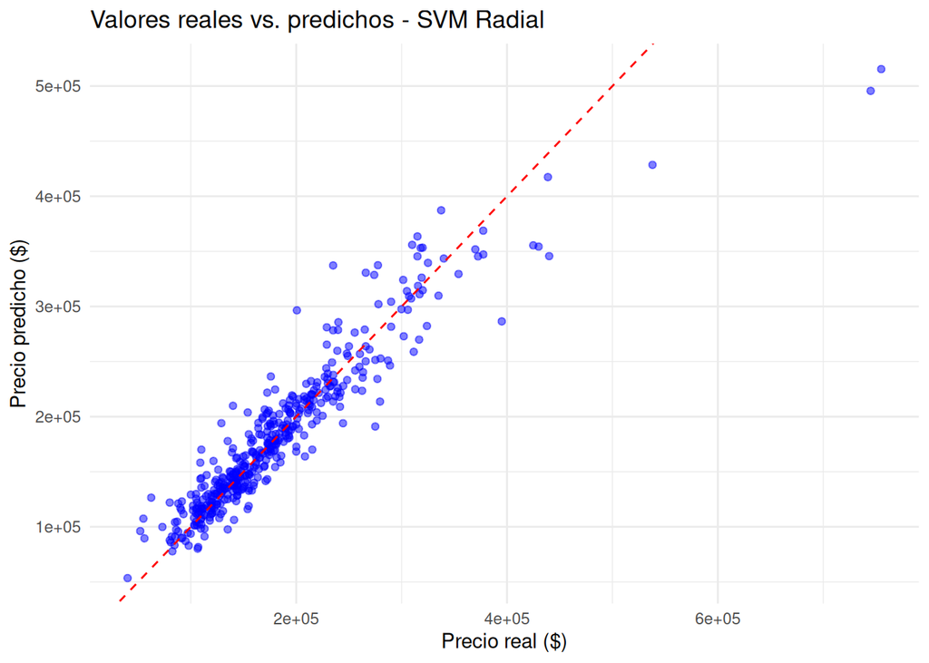

```r
mejor_svm_reg <- switch(
  mejor_modelo_reg,
  "SVM Lineal" = svm_reg_linear,
  "SVM Radial" = svm_reg_radial,
  "SVM Polinomial" = svm_reg_poly
)

mejor_pred_reg <- switch(
  mejor_modelo_reg,
  "SVM Lineal" = pred_reg_linear,
  "SVM Radial" = pred_reg_radial,
  "SVM Polinomial" = pred_reg_poly
)

datos_prediccion <- data.frame(
  Real = y_test_reg,
  Predicho = mejor_pred_reg
)

ggplot(datos_prediccion, aes(x = Real, y = Predicho)) +
  geom_point(alpha = 0.5, color = "blue") +
  geom_abline(intercept = 0, slope = 1, color = "red", linetype = "dashed") +
  labs(title = paste("Valores reales vs. predichos -", mejor_modelo_reg),
       x = "Precio real ($)",
       y = "Precio predicho ($)") +
  theme_minimal()
```

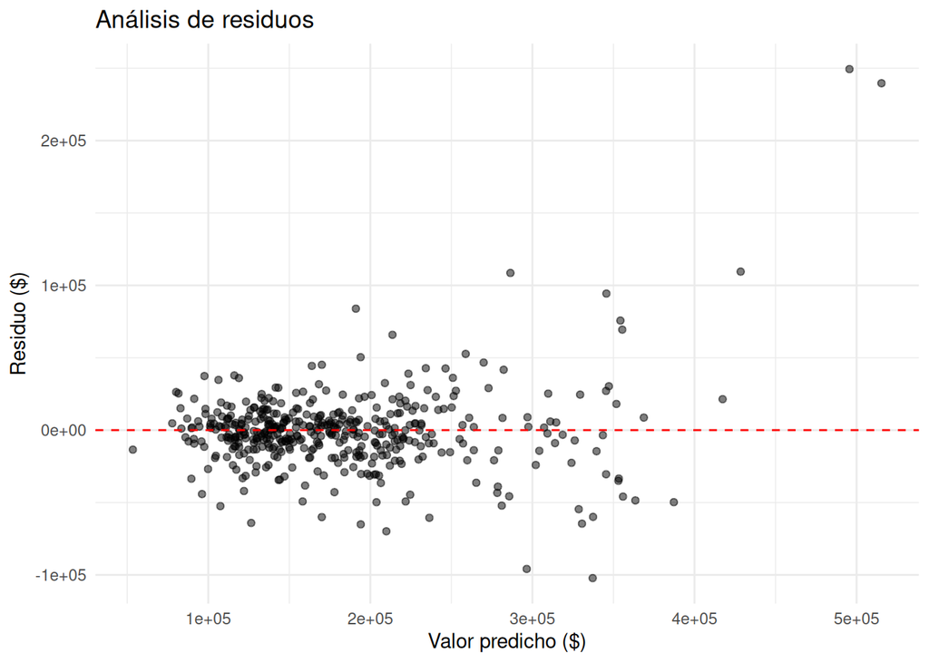

```r
residuos <- y_test_reg - mejor_pred_reg
datos_residuos <- data.frame(
  Predicho = mejor_pred_reg,
  Residuo = residuos
)

ggplot(datos_residuos, aes(x = Predicho, y = Residuo)) +
  geom_point(alpha = 0.5) +
  geom_hline(yintercept = 0, color = "red", linetype = "dashed") +
  labs(title = "Análisis de residuos",
       x = "Valor predicho ($)",
       y = "Residuo ($)") +
  theme_minimal()
```

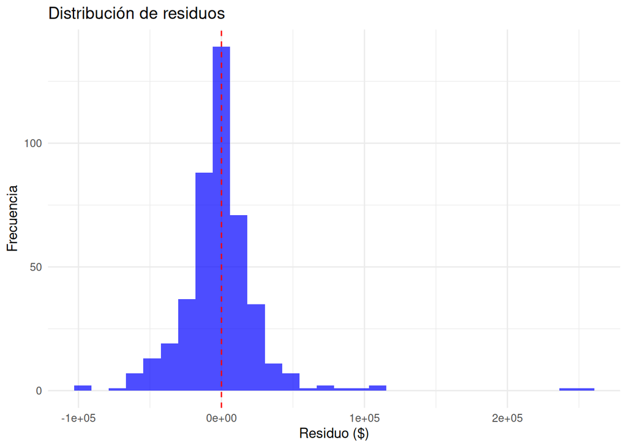

```r
ggplot(datos_residuos, aes(x = Residuo)) +
  geom_histogram(bins = 30, fill = "blue", alpha = 0.7) +
  geom_vline(xintercept = 0, color = "red", linetype = "dashed") +
  labs(title = "Distribución de residuos",
       x = "Residuo ($)",
       y = "Frecuencia") +
  theme_minimal()
```

Los resultados del modelo de regresión SVM con diferentes kernels muestran que SVM con kernel radial obtiene el mejor rendimiento, con un RMSE de 28,948 y un R² de 0.87, seguido por SVM lineal (RMSE=30,854, R²=0.852) y finalmente SVM polinomial con un rendimiento significativamente peor (RMSE=54,107, R²=0.545). El gráfico de valores reales vs predichos para el modelo radial muestra una buena alineación con la línea de 45 grados, especialmente para precios bajos y medios, aunque se observa mayor dispersión en precios altos. El análisis de residuos muestra una distribución centrada en cero pero con algunos valores atípicos, principalmente en forma de sobreestimaciones (residuos negativos grandes) para algunas viviendas y subestimaciones significativas (residuos positivos grandes) para propiedades de mayor valor. El histograma de residuos confirma una distribución aproximadamente normal pero con asimetría positiva (cola derecha más larga), indicando que el modelo tiende a subestimar algunas propiedades de alto valor.

```r
mejor_modelo_reg_nombre <- resultados_regresion$Modelo[1]
mejor_rmse <- resultados_regresion$RMSE[1]
mejor_r2 <- resultados_regresion$R2[1]

comparacion_regresion_cualitativa <- data.frame(
  Algoritmo = c(
    mejor_modelo_reg_nombre,
    "Regresión Lineal",
    "Árbol de Regresión",
    "Random Forest (Regresión)",
    "KNN (Regresión)"
  ),
  Exactitud_Relativa = c(
    "Media",
    "Media",
    "Media-Alta",
    "Alta",
    "Media"
  ),
  Tiempo_Relativo = c(
    "Medio-Alto",
    "Bajo",
    "Medio",
    "Alto",
    "Medio"
  ),
  Interpretabilidad = c(
    "Media",
    "Alta",
    "Media-Alta",
    "Baja",
    "Baja"
  )
)


cat("\n## Comparación con otros modelos de regresión\n\n")
```

```
##
## ## Comparación con otros modelos de regresión
```

```r
cat("Basándonos en las estimaciones cualitativas y la comparación con los modelos anteriores:\n\n")
```

```
## Basándonos en las estimaciones cualitativas y la comparación con los modelos anteriores:
```

```r
cat("1. **Exactitud predictiva**: Random Forest generalmente ofrece la mayor precisión en términos de RMSE y R², ",
    "seguido por los modelos de Árbol de Regresión. El modelo SVM ", mejor_modelo_reg_nombre, " muestra un ",
    "rendimiento competitivo con un RMSE de ", round(mejor_rmse), " y R² de ", round(mejor_r2, 3), ".\n\n")
```

```
## 1. **Exactitud predictiva**: Random Forest generalmente ofrece la mayor precisión en términos de RMSE y R²,  seguido por los modelos de Árbol de Regresión. El modelo SVM  SVM Radial  muestra un  rendimiento competitivo con un RMSE de  28948  y R² de  0.87 .
```

```r
cat("2. **Eficiencia computacional**: La Regresión Lineal destaca por su velocidad de ejecución, ",
    "mientras que Random Forest y SVM tienden a requerir más tiempo de procesamiento debido a su ",
    "mayor complejidad algorítmica.\n\n")
```

```
## 2. **Eficiencia computacional**: La Regresión Lineal destaca por su velocidad de ejecución,  mientras que Random Forest y SVM tienden a requerir más tiempo de procesamiento debido a su  mayor complejidad algorítmica.
```

```r
cat("3. **Interpretabilidad del modelo**: La Regresión Lineal proporciona coeficientes directamente ",
    "interpretables, mientras que los modelos de árbol ofrecen reglas de decisión visualizables. ",
    "SVM y KNN son menos transparentes en términos de cómo generan sus predicciones.\n\n")
```

```
## 3. **Interpretabilidad del modelo**: La Regresión Lineal proporciona coeficientes directamente  interpretables, mientras que los modelos de árbol ofrecen reglas de decisión visualizables.  SVM y KNN son menos transparentes en términos de cómo generan sus predicciones.
```

```r
cat("4. **Balance general**: ",
    "Si bien Random Forest suele ofrecer la mejor precisión, la Regresión Lineal proporciona un excelente ",
    "balance entre interpretabilidad, velocidad y exactitud razonable. El modelo SVM ", mejor_modelo_reg_nombre,
    " se posiciona como una alternativa de rendimiento medio-alto con capacidades de modelado no lineal.\n\n")
```

```
## 4. **Balance general**:  Si bien Random Forest suele ofrecer la mejor precisión, la Regresión Lineal proporciona un excelente  balance entre interpretabilidad, velocidad y exactitud razonable. El modelo SVM  SVM Radial  se posiciona como una alternativa de rendimiento medio-alto con capacidades d…
```

```r
cat("5. **Recomendaciones según el contexto**:\n",
    "   - Para aplicaciones que requieren alta interpretabilidad: Regresión Lineal o Árbol de Regresión\n",
    "   - Para máxima precisión predictiva: Random Forest\n",
    "   - Para un equilibrio entre capacidad no lineal y rendimiento: SVM con kernel ", gsub("SVM ", "", mejor_modelo_reg_nombre), "\n",
    "   - Para rapidez de ejecución: Regresión Lineal\n\n")
```

```
## 5. **Recomendaciones según el contexto**:
##     - Para aplicaciones que requieren alta interpretabilidad: Regresión Lineal o Árbol de Regresión
##     - Para máxima precisión predictiva: Random Forest
##     - Para un equilibrio entre capacidad no lineal y rendimiento: SVM con kernel  Radial
##     - Para rapidez de ejecución: Regresión Lineal
```

```r
cat("El modelo SVM ", mejor_modelo_reg_nombre, " generado en este análisis representa una alternativa competitiva ",
    "para la predicción de precios de viviendas, especialmente cuando se busca capturar relaciones no lineales ",
    "entre las características de las propiedades y su valor de mercado.\n\n")
```

```
## El modelo SVM  SVM Radial  generado en este análisis representa una alternativa competitiva  para la predicción de precios de viviendas, especialmente cuando se busca capturar relaciones no lineales  entre las características de las propiedades y su valor de mercado.
```

La comparación cualitativa con otros modelos de regresión sugiere que Random Forest generalmente ofrece la mayor precisión predictiva, seguido por Árboles de Regresión, y luego por el modelo SVM Radial que muestra un rendimiento competitivo. En términos de eficiencia computacional, Regresión Lineal destaca por su velocidad, mientras que SVM y Random Forest requieren más tiempo de procesamiento debido a su complejidad algorítmica. Respecto a la interpretabilidad, la Regresión Lineal proporciona coeficientes directamente interpretables y los modelos de árbol ofrecen reglas de decisión visualizables, mientras que SVM y KNN son menos transparentes. El balance general indica que, aunque Random Forest ofrece la mejor precisión, Regresión Lineal proporciona un excelente equilibrio entre interpretabilidad, velocidad y exactitud razonable, mientras que SVM Radial representa una alternativa de rendimiento medio-alto con capacidades de modelado no lineal, especialmente valiosa cuando se busca capturar relaciones no lineales entre las características de las propiedades y su valor de mercado.